# U1-Predicting-response-times-of-the-Paris-Fire_Brigade-vehicles

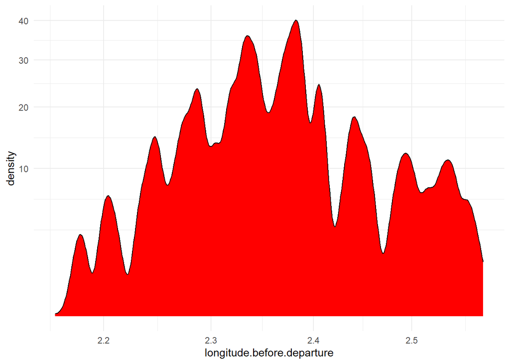

```r
data.quanti %>%
  ggplot(aes(longitude.before.departure)) +
  geom_density(fill = "red", bins = 100) +
  scale_x_log10() +
  scale_y_sqrt() +
  theme_minimal()
```

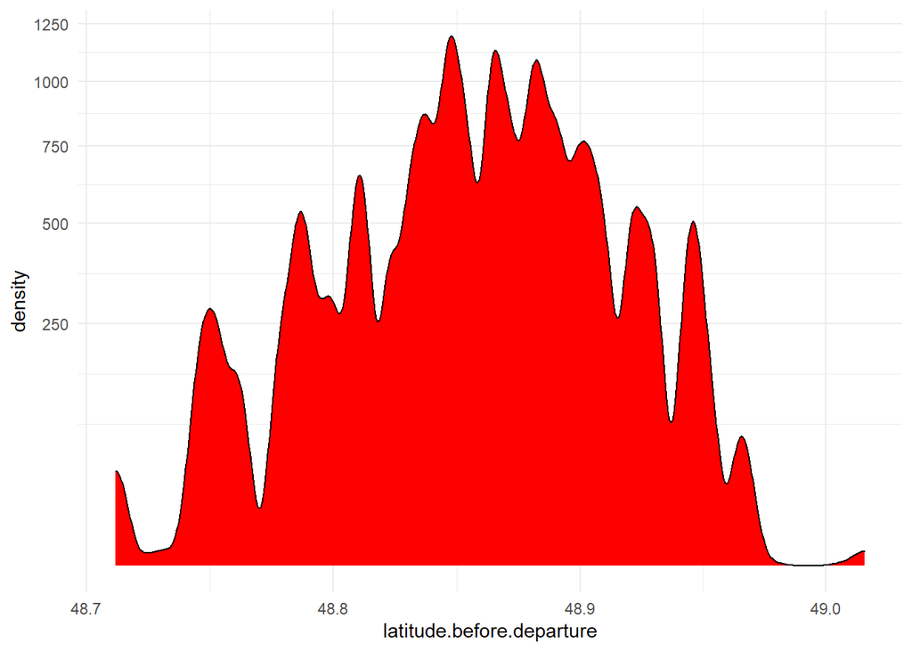

```r
data.quanti %>%
  ggplot(aes(latitude.before.departure)) +
  geom_density(fill = "red", bins = 100) +
  scale_x_log10() +
  scale_y_sqrt() +
  theme_minimal()
```

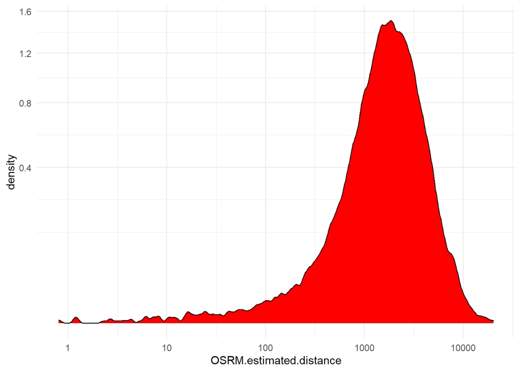

```r
data.quanti %>%
  ggplot(aes(OSRM.estimated.distance)) +
  geom_density(fill = "red", bins = 100) +
  scale_x_log10() +
  scale_y_sqrt() +
  theme_minimal()
```

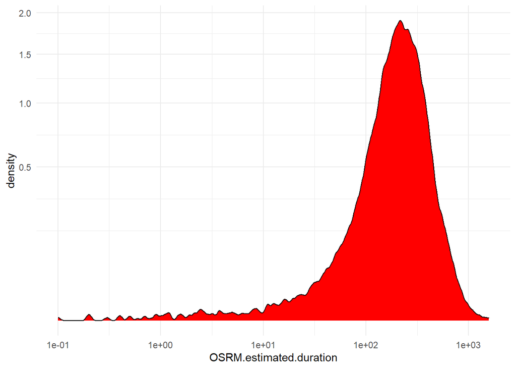

```r
data.quanti %>%
  ggplot(aes(OSRM.estimated.duration)) +
  geom_density(fill = "red", bins = 100) +
  scale_x_log10() +
  scale_y_sqrt() +
  theme_minimal()
```

##### 3.1.1.3 Boxplots

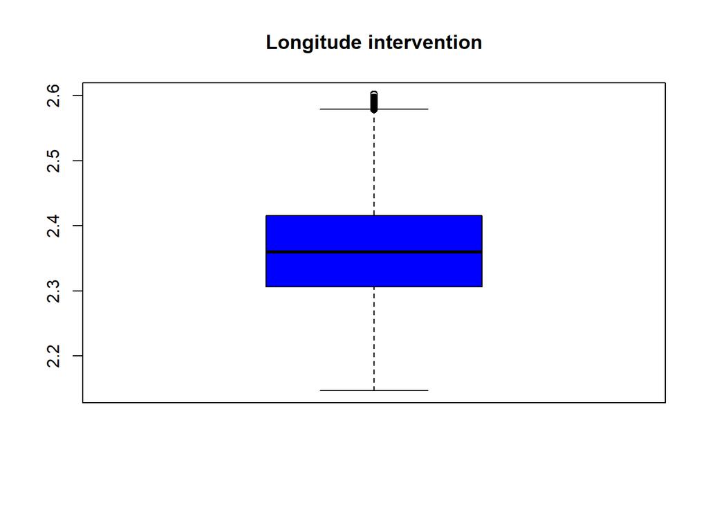

```r
boxplot(data.quanti$longitude.intervention, col="blue",main="Longitude intervention")
```

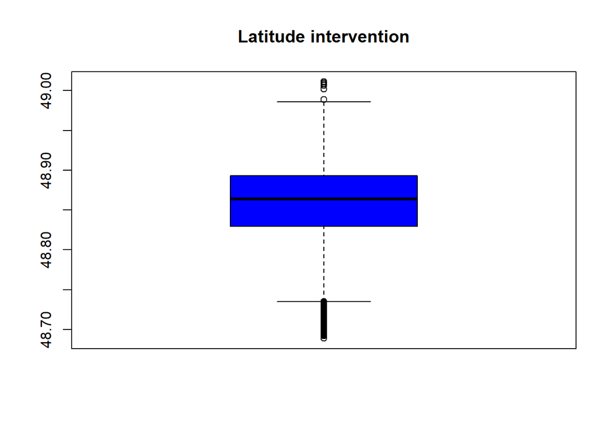

```r
boxplot(data.quanti$latitude.intervention, col="blue",main="Latitude intervention")
```

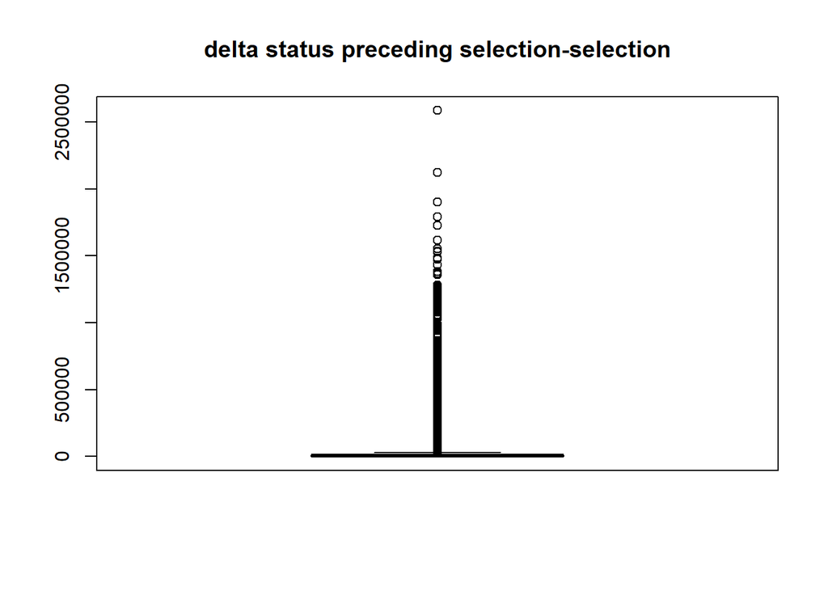

```r
boxplot(data.quanti$delta.status.preceding.selection.selection , col="blue",main="delta status preceding selection-selection")
```

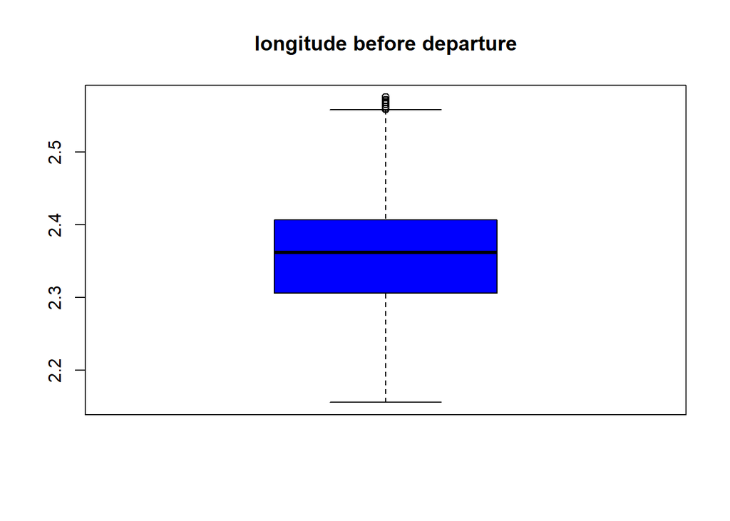

```r
boxplot(data.quanti$longitude.before.departure, col="blue",main="longitude before departure")
```

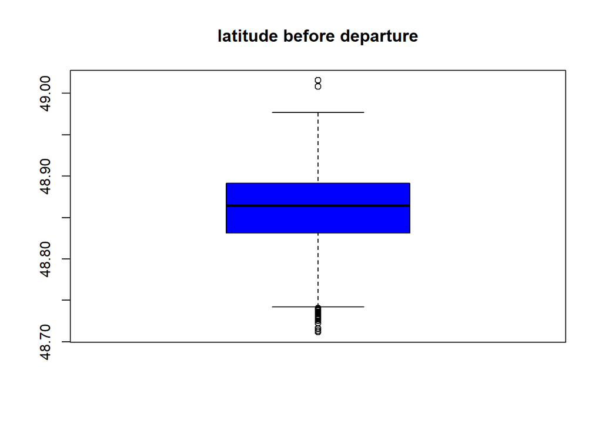

```r
boxplot(data.quanti$latitude.before.departure, col="blue",main="latitude before departure")
```

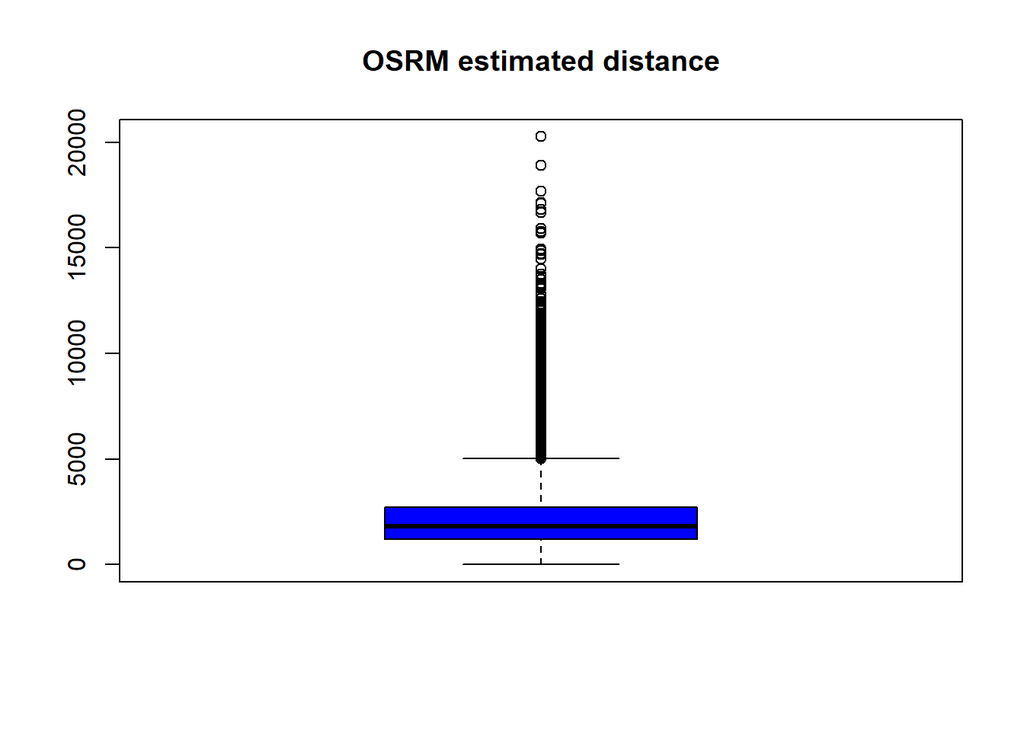

```r
boxplot(data.quanti$OSRM.estimated.distance, col="blue",main="OSRM estimated distance")
```

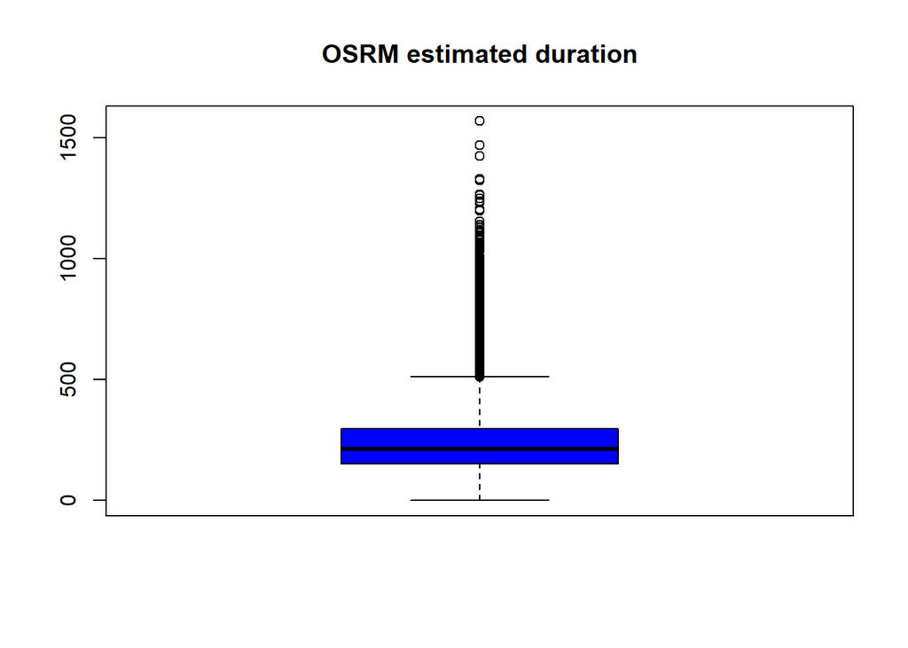

```r
boxplot(data.quanti$OSRM.estimated.duration, col="blue",main="OSRM estimated duration")
```

##### 3.1.1.3 Manage Outliers

```r
data.clean <- data[data$delta.status.preceding.selection.selection < 100000,]
data.clean <- data[data$OSRM.estimated.duration < 1000,]


#Assign the new value to data.quanti
colnames(data.clean)
```

```
##  [1] "emergency.vehicle.selection"
##  [2] "intervention"
##  [3] "alert.reason.category"
##  [4] "alert.reason"
##  [5] "intervention.on.public.roads"
##  [6] "floor"
##  [7] "location.of.the.event"
##  [8] "longitude.intervention"
##  [9] "latitude.intervention"
## [10] "emergency.vehicle"
## [11] "emergency.vehicle.type"
## [12] "rescue.center"
## [13] "date.key.selection"
## [14] "time.key.selection"
## [15] "status.preceding.selection"
## [16] "delta.status.preceding.selection.selection"
## [17] "departed.from.its.rescue.center"
## [18] "longitude.before.departure"
## [19] "latitude.before.departure"
## [20] "GPS.tracks.departure.presentation"
## [21] "GPS.tracks.datetime.departure.presentation"
## [22] "OSRM.estimated.distance"
## [23] "OSRM.estimated.duration"
## [24] "delta.selection.departure"
## [25] "delta.departure.presentation"
## [26] "delta.selection.presentation"
```

```r
data.quanti<-data.clean[,-c(3,4,5,6,7,10,11,12,15,17,24,25,26)]
data.quanti.y<-data.clean[,-c(3,4,5,6,7,10,11,12,15,17)]
```

#### 3.1.2 Qualitative Variables

##### 3.1.2.1 Tables

```r
str(data.quali)
```

```
## Classes 'data.table' and 'data.frame':   206627 obs. of  10 variables:
##  $ alert.reason.category          : Factor w/ 9 levels "1","2","3","4",..: 3 3 3 3 3 3 9 3 3 3 ...
##  $ alert.reason                   : Factor w/ 122 levels "1911","1912",..: 60 41 61 60 60 31 101 60 32 31 ...
##  $ intervention.on.public.roads   : Factor w/ 2 levels "0","1": 1 1 1 1 1 1 1 1 2 1 ...
##  $ floor                          : Factor w/ 45 levels "-10","-6","-5",..: 8 9 10 8 11 9 12 8 8 8 ...
##  $ location.of.the.event          : Factor w/ 210 levels "100","101","102",..: 48 36 39 36 5 56 36 36 48 94 ...
##  $ emergency.vehicle              : Factor w/ 639 levels "1815","1823",..: 398 334 396 517 473 330 293 575 398 606 ...
##  $ emergency.vehicle.type         : Factor w/ 41 levels "AR","BEAA BSPP",..: 37 24 37 37 37 37 24 37 37 37 ...
##  $ rescue.center                  : Factor w/ 79 levels "2418","2434",..: 15 30 6 72 42 55 42 16 15 50 ...
##  $ status.preceding.selection     : Factor w/ 2 levels "Disponible","RentrÃ©": 2 2 1 2 2 2 2 2 2 2 ...
##  $ departed.from.its.rescue.center: Factor w/ 2 levels "0","1": 2 2 1 2 2 2 2 2 2 2 ...
##  - attr(*, ".internal.selfref")=<externalptr>
```

```r
table(data.quali$alert.reason.category)
```

```
##
##      1      2      3      4      5      6      7      8      9
##  15032   5402 172294   1185    614   4019    715    188   7178
```

```r
prop.table(table(data.quali$alert.reason.category))
```

```
##
##            1            2            3            4            5            6
## 0.0727494471 0.0261437276 0.8338406888 0.0057349717 0.0029715381 0.0194505074
##            7            8            9
## 0.0034603416 0.0009098521 0.0347389257
```

```r
table(data.quali$alert.reason)
```

```
##
##  1911  1912  1914  1918  1920  1922  1923  1924  1926  1927  1929  1932  1934
##   111   699   977  1305     3  8426   261   264     5    24   575     3     2
##  1940  1941  1942  1944  1951  1952  2011  2012  2014  2015  2017  2018  2020
##   433  1911     6     2    23     2  1914    22     3    21  1490  1934     4
##  2021  2022  2026  2028  2112  2113  2115  2116  2118  2119  2120  2121  2122
##     3     3     5     3 36679 22790    82   511  1722  2164  3327    62    11
##  2123  2124  2126  2127  2128  2129  2131  2132  2133  2134  2135  2136  2137
##    17  5693   184     1     1    73    33   791     6  3362  7498  1661    43
##  2141  2142  2143  2144  2145  2146  2147  2162  2163  2210  2211  2212  2213
##   457    18   341    10     1     8    66 66311 15052     4    28   556    17
##  2214  2215  2216  2218  2221  2311  2312  2313  2314  2317  2411  2412  2413
##   358     3   212     1     9   162   143   229    79     1   163    93     1
##  2414  2416  2421  2422  2423  2424  2426  2430  2431  2432  2511  2514  2519
##     3     6  2350   164    28    19   621     2   240    45    21    30     1
##  2523  2524  2525  2532  2612  2613  2614  2623  2624  2711  2712  2714  2715
##    79   467    55    62     1     2    10   165    10  5744    13     5     2
##  2716  2720  2724  2725  2727  2752  2753  4926  5061  5062  5811  7912  7913
##  1185    84    16    18     1    56    10    12   369  2934     1    57   162
##  7914 10821 10971 11021 93529
##    65     1     1     5    37
```

```r
prop.table(table(data.quali$alert.reason))
```

```
##
##         1911         1912         1914         1918         1920         1922
## 5.371999e-04 3.382907e-03 4.728327e-03 6.315728e-03 1.451892e-05 4.077879e-02
##         1923         1924         1926         1927         1929         1932
## 1.263146e-03 1.277665e-03 2.419819e-05 1.161513e-04 2.782792e-03 1.451892e-05
##         1934         1940         1941         1942         1944         1951
## 9.679277e-06 2.095564e-03 9.248549e-03 2.903783e-05 9.679277e-06 1.113117e-04
##         1952         2011         2012         2014         2015         2017
## 9.679277e-06 9.263068e-03 1.064720e-04 1.451892e-05 1.016324e-04 7.211061e-03
##         2018         2020         2021         2022         2026         2028
## 9.359861e-03 1.935855e-05 1.451892e-05 1.451892e-05 2.419819e-05 1.451892e-05
##         2112         2113         2115         2116         2118         2119
## 1.775131e-01 1.102954e-01 3.968504e-04 2.473055e-03 8.333858e-03 1.047298e-02
##         2120         2121         2122         2123         2124         2126
## 1.610148e-02 3.000576e-04 5.323602e-05 8.227386e-05 2.755206e-02 8.904935e-04
##         2127         2128         2129         2131         2132         2133
## 4.839639e-06 4.839639e-06 3.532936e-04 1.597081e-04 3.828154e-03 2.903783e-05
##         2134         2135         2136         2137         2141         2142
## 1.627086e-02 3.628761e-02 8.038640e-03 2.081045e-04 2.211715e-03 8.711349e-05
##         2143         2144         2145         2146         2147         2162
## 1.650317e-03 4.839639e-05 4.839639e-06 3.871711e-05 3.194161e-04 3.209213e-01
##         2163         2210         2211         2212         2213         2214
## 7.284624e-02 1.935855e-05 1.355099e-04 2.690839e-03 8.227386e-05 1.732591e-03
##         2215         2216         2218         2221         2311         2312
## 1.451892e-05 1.026003e-03 4.839639e-06 4.355675e-05 7.840214e-04 6.920683e-04
##         2313         2314         2317         2411         2412         2413
## 1.108277e-03 3.823314e-04 4.839639e-06 7.888611e-04 4.500864e-04 4.839639e-06
##         2414         2416         2421         2422         2423         2424
## 1.451892e-05 2.903783e-05 1.137315e-02 7.937007e-04 1.355099e-04 9.195313e-05
##         2426         2430         2431         2432         2511         2514
## 3.005416e-03 9.679277e-06 1.161513e-03 2.177837e-04 1.016324e-04 1.451892e-04
##         2519         2523         2524         2525         2532         2612
## 4.839639e-06 3.823314e-04 2.260111e-03 2.661801e-04 3.000576e-04 4.839639e-06
##         2613         2614         2623         2624         2711         2712
## 9.679277e-06 4.839639e-05 7.985404e-04 4.839639e-05 2.779888e-02 6.291530e-05
##         2714         2715         2716         2720         2724         2725
## 2.419819e-05 9.679277e-06 5.734972e-03 4.065296e-04 7.743422e-05 8.711349e-05
##         2727         2752         2753         4926         5061         5062
## 4.839639e-06 2.710198e-04 4.839639e-05 5.807566e-05 1.785827e-03 1.419950e-02
##         5811         7912         7913         7914        10821        10971
## 4.839639e-06 2.758594e-04 7.840214e-04 3.145765e-04 4.839639e-06 4.839639e-06
##        11021        93529
## 2.419819e-05 1.790666e-04
```

According to the previous results, we need to combine several categories for the alert reason variable. However, we don’t have enough information for grouping levels of that variable.

```r
table(data.quali$intervention.on.public.roads)
```

```
##
##      0      1
## 174494  32133
```

```r
prop.table(table(data.quali$intervention.on.public.roads))
```

```
##
##         0         1
## 0.8444879 0.1555121
```

```r
table(data.quali$floor)
```

```
##
##    -10     -6     -5     -4     -3     -2     -1      0      1      2      3
##      1      5      5    113    141    612   3702 127325  17707  14725  12298
##      4      5      6      7      8      9     10     11     12     13     14
##   9770   6892   4708   2756   1691   1121    789    564    418    316    250
##     15     16     17     18     19     20     21     22     23     24     25
##    182    131    134     73     25     14     23     23     11     12      8
##     26     27     28     29     30     31     32     33     37     52     79
##     15     17      3     12     10      1      7      2      4      1      1
##    100
##      9
```

```r
prop.table(table(data.quali$floor))
```

```
##
##          -10           -6           -5           -4           -3           -2
## 4.839639e-06 2.419819e-05 2.419819e-05 5.468792e-04 6.823890e-04 2.961859e-03
##           -1            0            1            2            3            4
## 1.791634e-02 6.162070e-01 8.569548e-02 7.126368e-02 5.951788e-02 4.728327e-02
##            5            6            7            8            9           10
## 3.335479e-02 2.278502e-02 1.333804e-02 8.183829e-03 5.425235e-03 3.818475e-03
##           11           12           13           14           15           16
## 2.729556e-03 2.022969e-03 1.529326e-03 1.209910e-03 8.808142e-04 6.339927e-04
##           17           18           19           20           21           22
## 6.485116e-04 3.532936e-04 1.209910e-04 6.775494e-05 1.113117e-04 1.113117e-04
##           23           24           25           26           27           28
## 5.323602e-05 5.807566e-05 3.871711e-05 7.259458e-05 8.227386e-05 1.451892e-05
##           29           30           31           32           33           37
## 5.807566e-05 4.839639e-05 4.839639e-06 3.387747e-05 9.679277e-06 1.935855e-05
##           52           79          100
## 4.839639e-06 4.839639e-06 4.355675e-05
```

According to the previous results, we need to combine several categories for the floor variable.

```r
table(data.quali$location.of.the.event)
```

```
##
##   100   101   102   103   104   105   106   107   108   109   110   111   112
##  2357   388     6    93  2687  1354   161  4869   350     2    50   498   579
##   113   114   115   116   118   119   120   121   122   123   124   125   126
##   146   677   228    14   315    26    94   181    16    61     2   124    24
##   127   128   129   130   131   132   133   134   135   136   137   138   139
##   308   513    13   401  3130    54   120   304  1796 44400  4679   516 51031
##   140   141   142   143   144   145   146   147   148   149   150   151   153
##  5237   235    90   562     8     9   320  1024 31997  9905     5     1     2
##   154   155   156   157   158   159   160   162   163   164   165   166   167
##     3    18    18   149    30     2     1    15    11   709   100    72   364
##   168   169   170   171   172   174   175   177   178   179   180   181   182
##    74     6    14    21    12     6     4    12     9   142    28    74     8
##   183   184   186   187   188   189   190   191   192   193   194   195   196
##     2    19   111     7    16   115    17   260    34    18   107    70  1776
```

[output cut: 20 more lines]

```r
prop.table(table(data.quali$location.of.the.event))
```

```
##
##          100          101          102          103          104          105
## 1.140703e-02 1.877780e-03 2.903783e-05 4.500864e-04 1.300411e-02 6.552871e-03
##          106          107          108          109          110          111
## 7.791818e-04 2.356420e-02 1.693874e-03 9.679277e-06 2.419819e-04 2.410140e-03
##          112          113          114          115          116          118
## 2.802151e-03 7.065872e-04 3.276435e-03 1.103438e-03 6.775494e-05 1.524486e-03
##          119          120          121          122          123          124
## 1.258306e-04 4.549260e-04 8.759746e-04 7.743422e-05 2.952180e-04 9.679277e-06
##          125          126          127          128          129          130
## 6.001152e-04 1.161513e-04 1.490609e-03 2.482735e-03 6.291530e-05 1.940695e-03
##          131          132          133          134          135          136
## 1.514807e-02 2.613405e-04 5.807566e-04 1.471250e-03 8.691991e-03 2.148800e-01
##          137          138          139          140          141          142
## 2.264467e-02 2.497254e-03 2.469716e-01 2.534519e-02 1.137315e-03 4.355675e-04
##          143          144          145          146          147          148
## 2.719877e-03 3.871711e-05 4.355675e-05 1.548684e-03 4.955790e-03 1.548539e-01
##          149          150          151          153          154          155
## 4.793662e-02 2.419819e-05 4.839639e-06 9.679277e-06 1.451892e-05 8.711349e-05
##          156          157          158          159          160          162
## 8.711349e-05 7.211061e-04 1.451892e-04 9.679277e-06 4.839639e-06 7.259458e-05
##          163          164          165          166          167          168
## 5.323602e-05 3.431304e-03 4.839639e-04 3.484540e-04 1.761628e-03 3.581333e-04
##          169          170          171          172          174          175
## 2.903783e-05 6.775494e-05 1.016324e-04 5.807566e-05 2.903783e-05 1.935855e-05
##          177          178          179          180          181          182
## 5.807566e-05 4.355675e-05 6.872287e-04 1.355099e-04 3.581333e-04 3.871711e-05
##          183          184          186          187          188          189
## 9.679277e-06 9.195313e-05 5.371999e-04 3.387747e-05 7.743422e-05 5.565584e-04
##          190          191          192          193          194          195
## 8.227386e-05 1.258306e-03 1.645477e-04 8.711349e-05 5.178413e-04 3.387747e-04
##          196          197          198          199          200          201
## 8.595198e-03 5.323602e-05 1.413174e-03 3.799116e-03 4.839639e-06 3.615210e-03
##          202          203          204          205          206          207
## 6.277011e-03 7.985404e-04 1.359938e-03 2.250432e-03 2.313347e-03 9.630881e-04
##          208          209          210          211          212          213
## 4.452467e-04 6.533512e-04 5.033224e-03 3.692644e-03 9.388899e-04 4.839639e-06
##          214          215          216          217          218          219
## 3.145765e-04 4.839639e-06 3.010255e-03 3.920107e-04 4.074976e-03 9.030766e-03
##          220          221          222          223          224          225
```

[output cut: 16 more lines]

```
## 1.500288e-04 2.986057e-03 8.227386e-05 6.146341e-04 4.839639e-05 9.679277e-06
##          280          282          284          285          286          287
## 2.419819e-05 1.451892e-05 4.839639e-06 1.451892e-05 9.146917e-04 2.903783e-05
##          288          289          290          291          292          293
## 2.323027e-04 1.935855e-05 4.839639e-06 5.807566e-05 9.679277e-06 4.839639e-06
##          294          295          296          297          298          299
## 1.645477e-04 8.227386e-05 9.679277e-05 9.679277e-06 1.451892e-05 9.679277e-06
##          300          301          302          303          305          306
## 1.548684e-04 1.451892e-05 4.839639e-06 1.451892e-05 3.387747e-05 1.451892e-05
##          307          308          309          310          311          312
## 5.807566e-05 3.871711e-04 1.500288e-04 2.903783e-05 9.679277e-06 1.839063e-04
##          313          315          316          317          318          319
## 9.679277e-06 9.679277e-06 6.533512e-04 1.645477e-04 3.871711e-05 1.016324e-04
##          320          321          322          323          324          325
## 5.323602e-04 1.984252e-04 6.920683e-04 2.850547e-03 4.839639e-06 1.167805e-02
```

```r
table(data.quali$emergency.vehicle)
```

```
##
## 1815 1823 1828 1832 1834 1843 1844 1847 1856 1859 1867 1877 1879 1880 1893 1895
##   61   62  210  281  272   11   96  221   92  157   17    2  503  103   99    2
## 1901 1910 1913 1914 1926 1933 1941 1943 1952 1969 1980 1985 1986 1991 1992 1994
##  328  328  716  240   59    1  130   52  494  287    8  264  191   34  457  160
## 1996 2004 2008 2019 2021 2022 2047 2053 2056 2062 2065 2067 2068 2094 2098 2100
##   39   36  494  261  157   72  307   46  150   19  608  468   30  247    5  496
## 2105 2115 2118 2125 2132 2144 2145 2151 2154 2171 2174 2207 2216 2219 2221 2231
##  107  288  339  380  127  128    6   15  239  325   19    4  199  243  104   46
## 2241 2242 2244 2252 2253 2255 2276 2280 2281 2289 2290 2291 2292 2293 2294 2296
##  378  155  204   33  543  284   27  300   60  662  265   15   51  277  341   39
## 2297 2298 2302 2303 2304 2307 2308 2311 2312 2319 2321 2324 2326 2327 2329 2339
##  278   53   50  407   10   39  269   60  225   31   60  284  406   61   91   57
## 2348 2349 2364 2403 2407 2414 2417 2418 2419 2420 2422 2426 2428 2429 2432 2434
##  185  354  169   47    3   32   25  435   36    6   11  147  217  175  177   34
```

[output cut: 66 more lines]

```r
prop.table(table(data.quali$emergency.vehicle))
```

```
##
##         1815         1823         1828         1832         1834         1843
## 2.952180e-04 3.000576e-04 1.016324e-03 1.359938e-03 1.316382e-03 5.323602e-05
##         1844         1847         1856         1859         1867         1877
## 4.646053e-04 1.069560e-03 4.452467e-04 7.598233e-04 8.227386e-05 9.679277e-06
##         1879         1880         1893         1895         1901         1910
## 2.434338e-03 4.984828e-04 4.791242e-04 9.679277e-06 1.587401e-03 1.587401e-03
##         1913         1914         1926         1933         1941         1943
## 3.465181e-03 1.161513e-03 2.855387e-04 4.839639e-06 6.291530e-04 2.516612e-04
##         1952         1969         1980         1985         1986         1991
## 2.390781e-03 1.388976e-03 3.871711e-05 1.277665e-03 9.243710e-04 1.645477e-04
##         1992         1994         1996         2004         2008         2019
## 2.211715e-03 7.743422e-04 1.887459e-04 1.742270e-04 2.390781e-03 1.263146e-03
##         2021         2022         2047         2053         2056         2062
## 7.598233e-04 3.484540e-04 1.485769e-03 2.226234e-04 7.259458e-04 9.195313e-05
##         2065         2067         2068         2094         2098         2100
## 2.942500e-03 2.264951e-03 1.451892e-04 1.195391e-03 2.419819e-05 2.400461e-03
##         2105         2115         2118         2125         2132         2144
## 5.178413e-04 1.393816e-03 1.640637e-03 1.839063e-03 6.146341e-04 6.194737e-04
##         2145         2151         2154         2171         2174         2207
## 2.903783e-05 7.259458e-05 1.156674e-03 1.572883e-03 9.195313e-05 1.935855e-05
##         2216         2219         2221         2231         2241         2242
## 9.630881e-04 1.176032e-03 5.033224e-04 2.226234e-04 1.829383e-03 7.501440e-04
##         2244         2252         2253         2255         2276         2280
## 9.872863e-04 1.597081e-04 2.627924e-03 1.374457e-03 1.306702e-04 1.451892e-03
##         2281         2289         2290         2291         2292         2293
## 2.903783e-04 3.203841e-03 1.282504e-03 7.259458e-05 2.468216e-04 1.340580e-03
##         2294         2296         2297         2298         2302         2303
## 1.650317e-03 1.887459e-04 1.345420e-03 2.565008e-04 2.419819e-04 1.969733e-03
##         2304         2307         2308         2311         2312         2319
## 4.839639e-05 1.887459e-04 1.301863e-03 2.903783e-04 1.088919e-03 1.500288e-04
##         2321         2324         2326         2327         2329         2339
## 2.903783e-04 1.374457e-03 1.964893e-03 2.952180e-04 4.404071e-04 2.758594e-04
##         2348         2349         2364         2403         2407         2414
## 8.953331e-04 1.713232e-03 8.178989e-04 2.274630e-04 1.451892e-05 1.548684e-04
##         2417         2418         2419         2420         2422         2426
## 1.209910e-04 2.105243e-03 1.742270e-04 2.903783e-05 5.323602e-05 7.114269e-04
##         2428         2429         2432         2434         2456         2473
## 1.050202e-03 8.469368e-04 8.566160e-04 1.645477e-04 1.451892e-05 9.630881e-04
##         2476         2477         2478         2485         2493         2496
```

[output cut: 160 more lines]

```
## 2.565008e-04 1.016324e-03 1.306702e-04 1.340580e-03 1.195391e-03 1.805185e-03
##         5975         5982         5995         5996         5997         5998
## 4.839639e-06 3.194161e-04 4.839639e-06 3.310313e-03 3.508738e-03 8.716189e-03
##         6000         6001         6002         6003         6004         6005
## 6.669022e-03 4.045938e-03 7.646629e-03 2.124601e-03 6.330247e-03 6.160860e-03
##         6008         6030         6032         6033         6035         6037
## 4.839639e-06 1.790666e-04 7.259458e-04 1.935855e-05 6.678701e-04 2.995736e-03
##         6038         6039         6041         6042         6043         6044
## 2.652122e-03 3.155444e-03 1.747110e-03 3.479700e-03 4.839639e-06 1.935855e-05
##         6045         6046         6047         6048         6049         6051
## 1.742270e-04 1.839063e-04 1.839063e-04 1.064720e-04 1.108277e-03 2.371423e-04
##         6052         6053         6055         6056         6064         6065
## 2.565008e-04 2.032648e-04 1.984252e-04 2.419819e-05 1.558364e-03 3.179643e-03
##         6067         6080         6092
## 2.918302e-03 1.161513e-04 1.451892e-05
```

```r
table(data.quali$emergency.vehicle.type)
```

```
##
##         AR  BEAA BSPP         CA   CCR BSPP    CD BSPP        CFS       CRAC
##        766        307          6       1285         21          8         21
##        CRF        DAP        DEP   EPA BSPP       EPAN       EPSA       ESAV
##       1417          1          4       1322       1247        339          1
##         FA       FFSS FMOGP BSPP       FNPC   FPT BSPP  FPT SSLIA  FPTL BSPP
##       2228        126          1        856       3607          1        288
##      OHFOM        PEV        PSE        PST       SFCB         SP       SPTT
##         83          7      30149         17         50          3          1
##       UMPS        VID       VLHP   VLR BSPP        VPS        VRA        VRM
##         29        666         37       4154        151          3          6
##  VSAV BALA  VSAV BSPP  VSAV SDIS VSAV SSLIA       VSIS       VSTI
##          1     157393          2         20          2          1
```

```r
prop.table(table(data.quali$emergency.vehicle.type))
```

```
##
##           AR    BEAA BSPP           CA     CCR BSPP      CD BSPP          CFS
## 3.707163e-03 1.485769e-03 2.903783e-05 6.218936e-03 1.016324e-04 3.871711e-05
##         CRAC          CRF          DAP          DEP     EPA BSPP         EPAN
## 1.016324e-04 6.857768e-03 4.839639e-06 1.935855e-05 6.398002e-03 6.035029e-03
##         EPSA         ESAV           FA         FFSS   FMOGP BSPP         FNPC
## 1.640637e-03 4.839639e-06 1.078271e-02 6.097945e-04 4.839639e-06 4.142731e-03
##     FPT BSPP    FPT SSLIA    FPTL BSPP        OHFOM          PEV          PSE
## 1.745658e-02 4.839639e-06 1.393816e-03 4.016900e-04 3.387747e-05 1.459103e-01
##          PST         SFCB           SP         SPTT         UMPS          VID
## 8.227386e-05 2.419819e-04 1.451892e-05 4.839639e-06 1.403495e-04 3.223199e-03
##         VLHP     VLR BSPP          VPS          VRA          VRM    VSAV BALA
## 1.790666e-04 2.010386e-02 7.307854e-04 1.451892e-05 2.903783e-05 4.839639e-06
##    VSAV BSPP    VSAV SDIS   VSAV SSLIA         VSIS         VSTI
## 7.617252e-01 9.679277e-06 9.679277e-05 9.679277e-06 4.839639e-06
```

According to the results, we need to combine several categories for the emergency vehicle type variable. However, we don’t have enough information for grouping levels of that variable.

```r
table(data.quali$rescue.center)
```

```
##
##   2418   2434   2435   2436   2437   2438   2439   2440   2441   2442   2443
##     15   2325   1906   3481   3088   3079   3793   1321   4143   4219   3556
##   2444   2445   2446   2447   2448   2449   2450   2451   2452   2454   2455
##   3270   2851   4973   4825   3029   3713   3276   2512   2053   3123   2614
##   2456   2457   2458   2459   2460   2462   2463   2464   2465   2467   2469
##   2739   2489   2586   2030   4061   2630   4591   1848   2399   2756   4511
##   2470   2471   2472   2473   2474   2475   2476   2477   2478   2479   2480
##   2968   1076   2930   2257   4127   5607   1383   5637   3911   3201   3123
##   2481   2482   2483   2484   2485   2486   2487   2488   2489   2490   2491
##   2856   1416   2182   2799   2825   4472   1563   5122   2506   2186   3932
##   2492   2493   2494   2495   2496   2497   2498   2499   2500   2501   2503
##   2242   3136   1759   1235   1588   4443   1265   2588   2185   3037   1088
##   2505   2506   2507   2508   2509   2510 266281 266290 266294 266296 266321
##    622   2175   2874   1768   2620   2952      2   1150      3      1      3
## 266323 266324
##      6      1
```

```r
prop.table(table(data.quali$rescue.center))
```

```
##
##         2418         2434         2435         2436         2437         2438
## 7.259458e-05 1.125216e-02 9.224351e-03 1.684678e-02 1.494480e-02 1.490125e-02
##         2439         2440         2441         2442         2443         2444
## 1.835675e-02 6.393163e-03 2.005062e-02 2.041844e-02 1.720975e-02 1.582562e-02
##         2445         2446         2447         2448         2449         2450
## 1.379781e-02 2.406752e-02 2.335126e-02 1.465927e-02 1.796958e-02 1.585466e-02
##         2451         2452         2454         2455         2456         2457
## 1.215717e-02 9.935778e-03 1.511419e-02 1.265082e-02 1.325577e-02 1.204586e-02
##         2458         2459         2460         2462         2463         2464
## 1.251531e-02 9.824466e-03 1.965377e-02 1.272825e-02 2.221878e-02 8.943652e-03
##         2465         2467         2469         2470         2471         2472
## 1.161029e-02 1.333804e-02 2.183161e-02 1.436405e-02 5.207451e-03 1.418014e-02
##         2473         2474         2475         2476         2477         2478
## 1.092306e-02 1.997319e-02 2.713585e-02 6.693220e-03 2.728104e-02 1.892783e-02
##         2479         2480         2481         2482         2483         2484
## 1.549168e-02 1.511419e-02 1.382201e-02 6.852928e-03 1.056009e-02 1.354615e-02
##         2485         2486         2487         2488         2489         2490
## 1.367198e-02 2.164286e-02 7.564355e-03 2.478863e-02 1.212813e-02 1.057945e-02
##         2491         2492         2493         2494         2495         2496
## 1.902946e-02 1.085047e-02 1.517711e-02 8.512924e-03 5.976954e-03 7.685346e-03
##         2497         2498         2499         2500         2501         2503
## 2.150251e-02 6.122143e-03 1.252498e-02 1.057461e-02 1.469798e-02 5.265527e-03
##         2505         2506         2507         2508         2509         2510
## 3.010255e-03 1.052621e-02 1.390912e-02 8.556481e-03 1.267985e-02 1.428661e-02
##       266281       266290       266294       266296       266321       266323
## 9.679277e-06 5.565584e-03 1.451892e-05 4.839639e-06 1.451892e-05 2.903783e-05
##       266324
## 4.839639e-06
```

They are several levels which could be consider as outliers and we need to garbage them out.

```r
table(data.quali$status.preceding.selection)
```

```
##
## Disponible    RentrÃ©
##       4553     202074
```

```r
prop.table(table(data.quali$status.preceding.selection))
```

```
##
## Disponible    RentrÃ©
## 0.02203487 0.97796513
```

```r
table(data.quali$departed.from.its.rescue.center)
```

```
##
##      0      1
##   4553 202074
```

```r
prop.table(table(data.quali$departed.from.its.rescue.center))
```

```
##
##          0          1
## 0.02203487 0.97796513
```

##### 3.1.2.2 Barplots

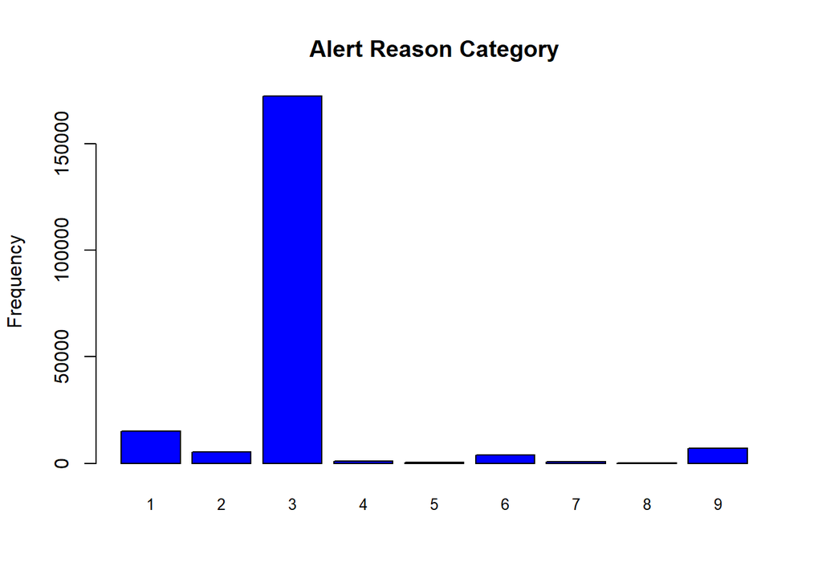

```r
barplot(table(data.quali$alert.reason.category),horiz = F,cex.names=0.8,col="blue",main="Alert Reason Category",ylab="Frequency", plot=TRUE)
```

[figure not shown]

```r
barplot(table(data.quali$alert.reason),horiz = F,cex.names=0.8,col="blue",main="Alert Reason Category",ylab="Frequency", plot=TRUE)
```

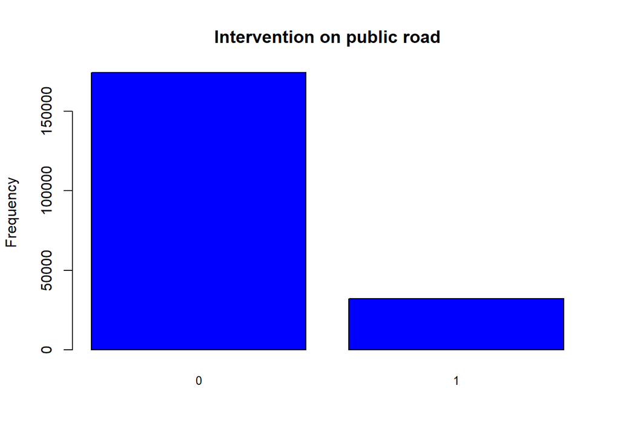

```r
barplot(table(data.quali$intervention.on.public.roads),horiz = F,cex.names=0.8,col="blue",main="Intervention on public road",ylab="Frequency", plot=TRUE)
```

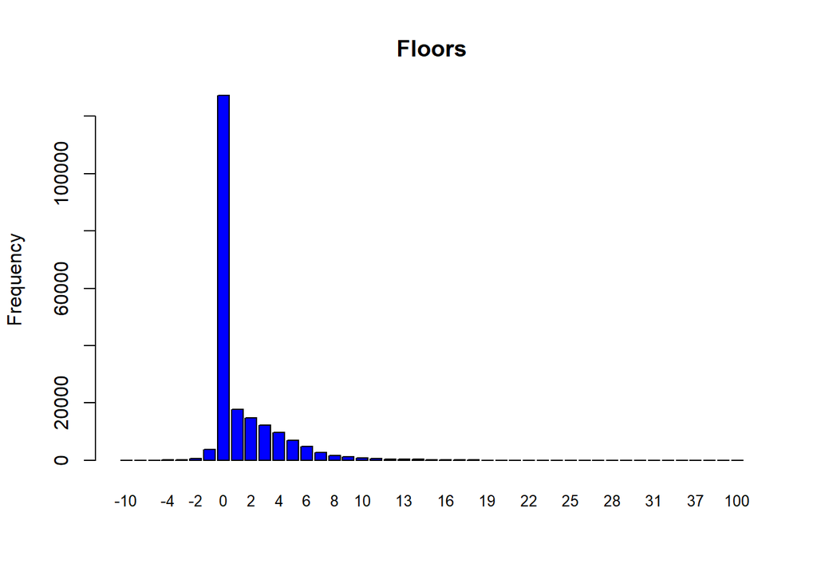

```r
barplot(table(data.quali$floor),horiz = F,cex.names=0.8,col="blue",main="Floors",ylab="Frequency", plot=TRUE)
```

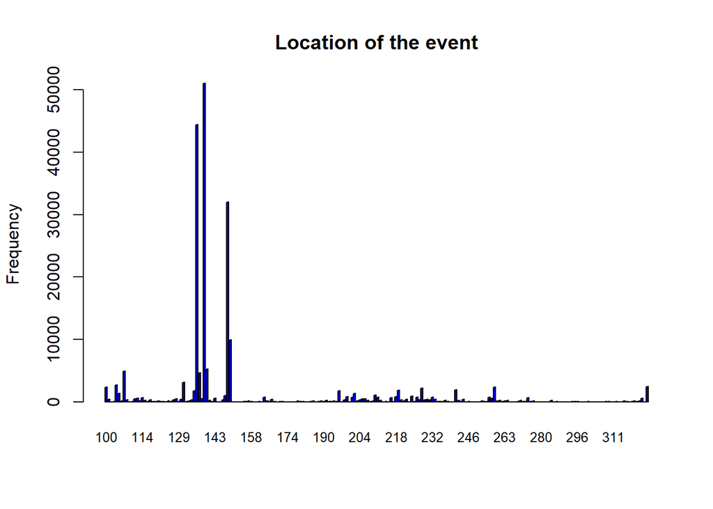

```r
barplot(table(data.quali$location.of.the.event),horiz = F,cex.names=0.8,col="blue",main="Location of the event",ylab="Frequency", plot=TRUE)
```

[figure not shown]

```r
barplot(table(data.quali$emergency.vehicle),horiz = F,cex.names=0.8,col="blue",main="Emergency Vehicle Type",ylab="Frequency", plot=TRUE)
```

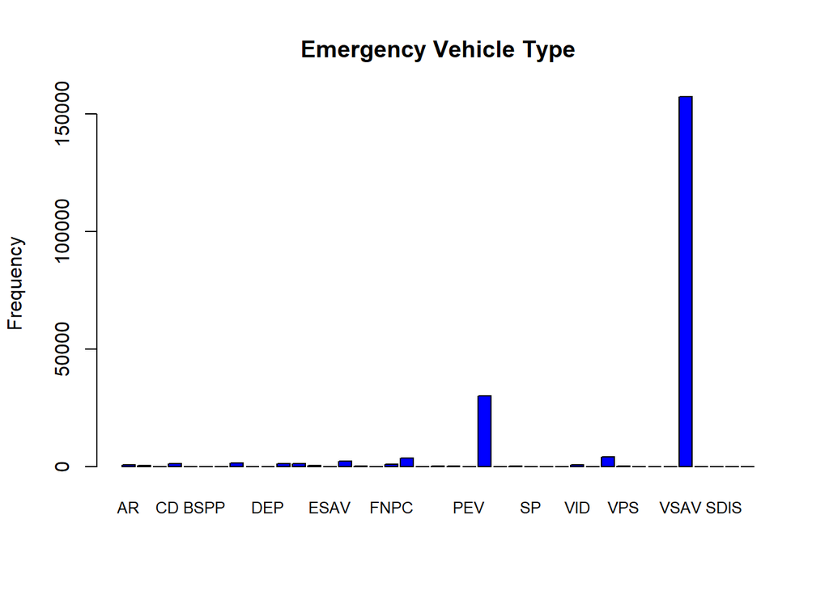

```r
barplot(table(data.quali$emergency.vehicle.type),horiz = F,cex.names=0.8,col="blue",main="Emergency Vehicle Type",ylab="Frequency", plot=TRUE)
```

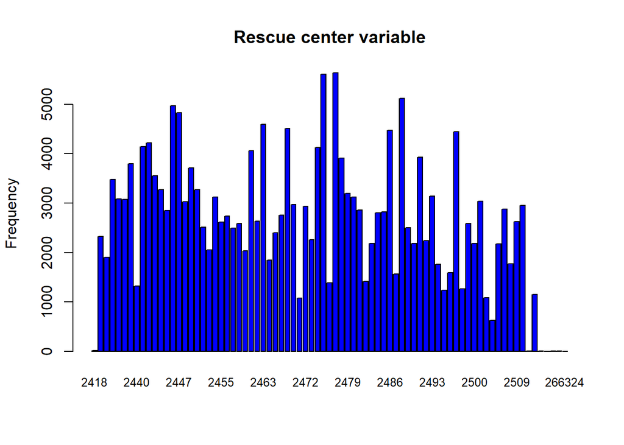

```r
barplot(table(data.quali$rescue.center),horiz = F,cex.names=0.8,col="blue",main="Rescue center variable",ylab="Frequency", plot=TRUE)
```

[figure not shown]

```r
barplot(table(data.quali$status.preceding.selection),horiz = F,cex.names=0.8,col="blue",main="Emergency Vehicle Type",ylab="Frequency", plot=TRUE)
```

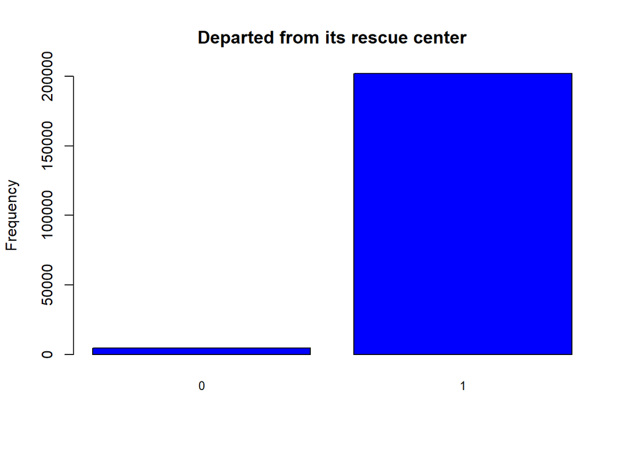

```r
barplot(table(data.quali$departed.from.its.rescue.center),horiz = F,cex.names=0.8,col="blue",main="Departed from its rescue center",ylab="Frequency", plot=TRUE)
```

##### 3.1.2.3 Group Together Categories With Low Frequency & Manage Outliers

for the floor variable, group everything below -2 & everything after 17

```r
table(data.clean$floor)
```

```
##
##    -10     -6     -5     -4     -3     -2     -1      0      1      2      3
##      1      5      5    112    140    605   3672 126288  17577  14629  12193
##      4      5      6      7      8      9     10     11     12     13     14
##   9705   6846   4667   2728   1673   1117    777    561    415    314    247
##     15     16     17     18     19     20     21     22     23     24     25
##    179    129    133     73     24     14     23     23     11     12      8
##     26     27     28     29     30     31     32     33     37     52     79
##     15     16      3     12     10      1      7      2      4      1      1
##    100
##      9
```

```r
levels(data.clean$floor)<-list("-2"=c("-10","-9","-6","-5","-4","-3", "-2"),"-1"=c("-1"),"0"=c("0"),"1"=c("1"),"2"=c("2"),"3"=c("3"),"4"=c("4"),"5"=c("5"),"6"=c("6"),"7"=c("7"),"8"=c("8"),"9"=c("9"),"10"=c("10"),"11"=c("11"),"12"=c("12"),"13"=c("13"),"14"=c("14"),"15"=c("15"),"16"=c("16"),"17"=c("17","18","19","20","21","22","23","24","25","26","27","28","29", "30", "31", "32", "33", "37","52","79","100"))


table(data.clean$floor)
```

```
##
##     -2     -1      0      1      2      3      4      5      6      7      8
##    868   3672 126288  17577  14629  12193   9705   6846   4667   2728   1673
##      9     10     11     12     13     14     15     16     17
##   1117    777    561    415    314    247    179    129    402
```

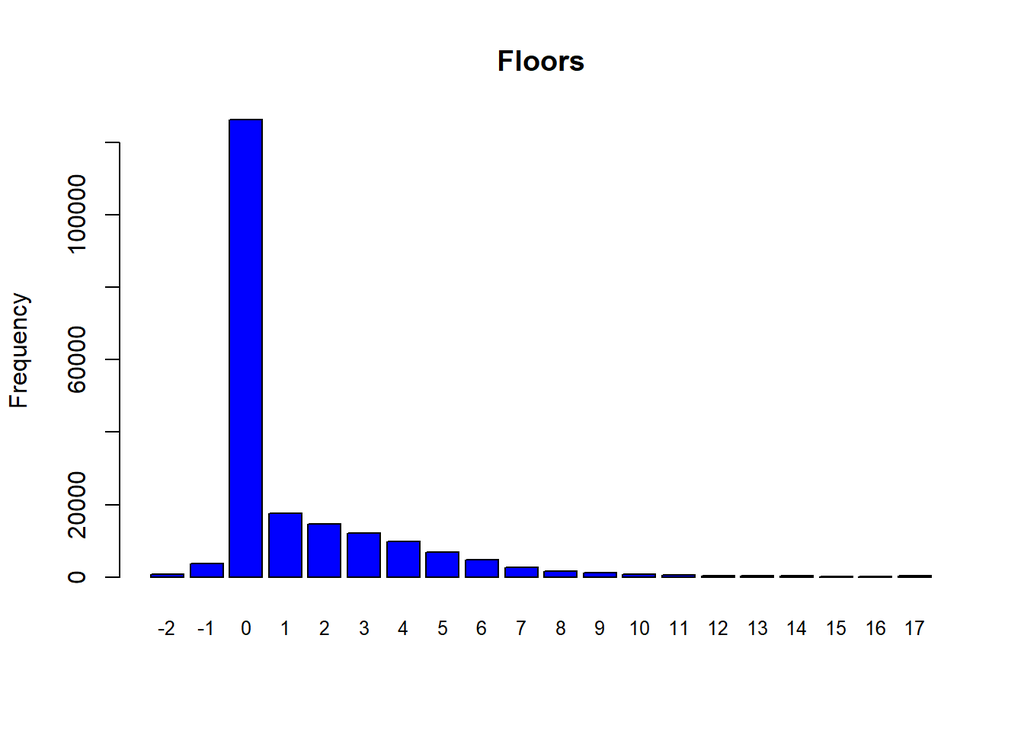

```r
barplot(table(data.clean$floor),horiz = F,cex.names=0.8,col="blue",main="Floors",ylab="Frequency", plot=TRUE)
```

```r
data.quali<-data.clean[,c(3,4,5,6,7,10,11,12,15,17)]
```

Apply same for x_test

```r
levels(x_test$floor)<-list("-2"=c("-10","-9","-6","-5","-4","-3", "-2"),"-1"=c("-1"),"0"=c("0"),"1"=c("1"),"2"=c("2"),"3"=c("3"),"4"=c("4"),"5"=c("5"),"6"=c("6"),"7"=c("7"),"8"=c("8"),"9"=c("9"),"10"=c("10"),"11"=c("11"),"12"=c("12"),"13"=c("13"),"14"=c("14"),"15"=c("15"),"16"=c("16"),"17"=c("17","18","19","20","21","22","23","24","25","26","27","28","29", "30", "31", "32", "33", "37","52","79","100"))
```

#### 3.1.2.4 Clean outliers for rescue.center

```r
table(data.quali$rescue.center)
```

```
##
##   2418   2434   2435   2436   2437   2438   2439   2440   2441   2442   2443
##     15   2314   1900   3466   3051   3060   3783   1306   4112   4169   3503
##   2444   2445   2446   2447   2448   2449   2450   2451   2452   2454   2455
##   3233   2840   4958   4780   2988   3696   3265   2487   2038   3085   2590
##   2456   2457   2458   2459   2460   2462   2463   2464   2465   2467   2469
##   2711   2457   2542   2010   4025   2586   4572   1819   2381   2740   4491
##   2470   2471   2472   2473   2474   2475   2476   2477   2478   2479   2480
##   2933   1058   2915   2207   4105   5575   1372   5607   3872   3184   3078
##   2481   2482   2483   2484   2485   2486   2487   2488   2489   2490   2491
##   2848   1403   2171   2787   2819   4456   1547   5113   2457   2178   3911
##   2492   2493   2494   2495   2496   2497   2498   2499   2500   2501   2503
##   2221   3110   1748   1213   1569   4401   1252   2577   2159   3013   1083
##   2505   2506   2507   2508   2509   2510 266281 266290 266294 266296 266321
##    615   2167   2845   1742   2608   2938      2   1146      2      1      2
## 266323 266324
##      3      1
```

We remove some levels (for data.clean$rescue.center variable) which are not significant for us because there are very few samples for them.

data.clean$rescue.center <- subset(data.clean$rescue.center, data.clean$rescue.center != “266281”)

data.clean <- data.clean[data.clean$rescue.center != 266281,]

data.clean <- data.clean[data.clean$rescue.center != 266294,]

data.clean <- data.clean[data.clean$rescue.center != 266296,]

data.clean <- data.clean[data.clean$rescue.center != 266321,]

data.clean <- data.clean[data.clean$rescue.center != 266323,]

data.clean <- data.clean[data.clean$rescue.center != 266324,]

table(droplevels(data.clean$rescue.center))

table(data.clean$rescue.center)

### 3.2. What is time difference between departure.presentation and OSRM estimated duration ?

Let’s compute time difference between departure.presentation(actual) and OSRM estimated duration (predicted). This difference can’t be taken into account in our future model.

```r
time.diff<-data.clean$delta.departure.presentation-data.clean$OSRM.estimated.duration
time.diff %>% head
```

```
## [1] 218.2  53.8  69.6  -6.6 260.4 231.3
```

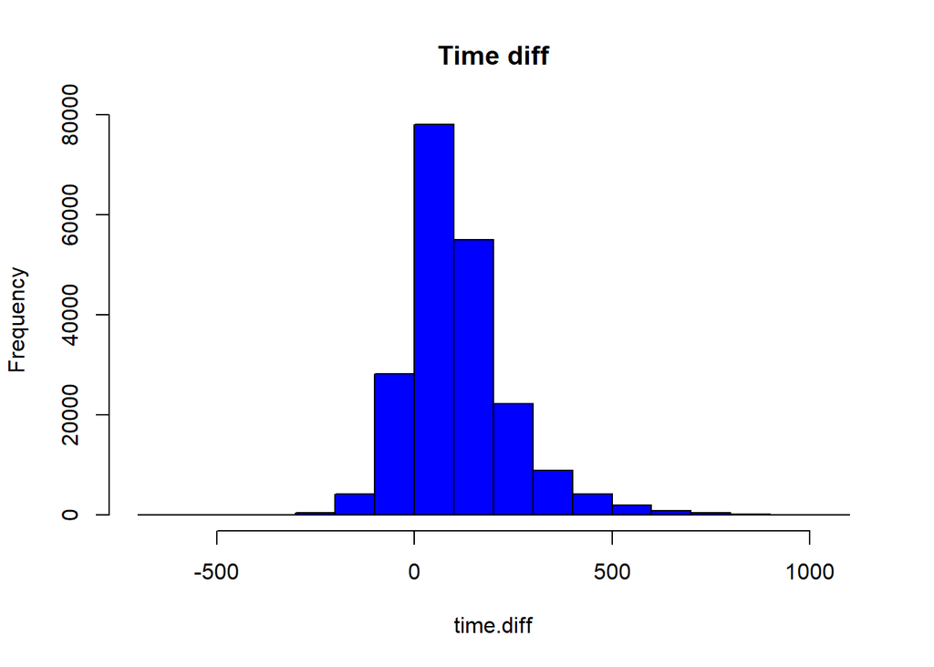

```r
hist(time.diff, col="blue",main="Time diff")
```

```r
summary(time.diff)
```

```
##    Min. 1st Qu.  Median    Mean 3rd Qu.    Max.
##  -640.6    27.1    89.0   110.8   169.2  1008.9
```

Here we can see that thre is a median 90 s (1min 30) of time diffirence between OSRM estimated duration and actual timing. One max at 1000 second. There is also min value which means that the brigate can also drive quickier than what OSRM predicted.

## 4. Feature engineering

### 4.1: Speed [km/h]

estimated speed by OSRM : distance / time

```r
data.fe<-data.clean
data.fe$OSRM.estimated.speed<-(data.clean$OSRM.estimated.distance/1000)/(data.clean$OSRM.estimated.duration/60^2)
data.fe$OSRM.estimated.speed %>% summary()
```

```
##    Min. 1st Qu.  Median    Mean 3rd Qu.    Max.
##   9.661  26.154  30.780  31.369  35.601  69.382
```

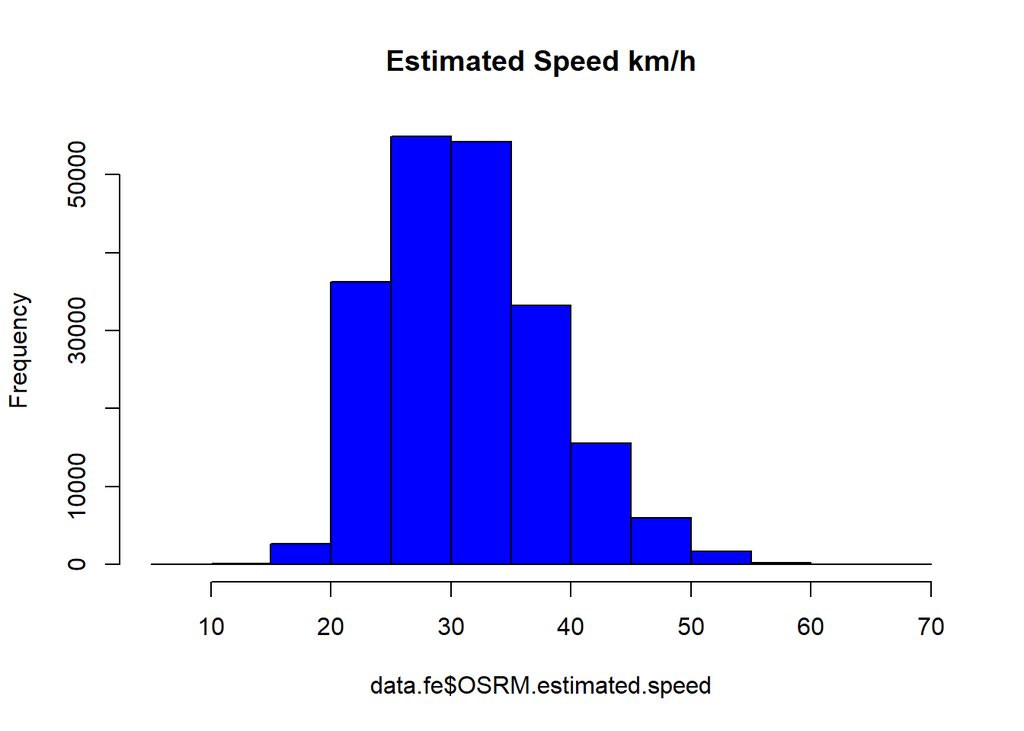

```r
hist(data.fe$OSRM.estimated.speed , col="blue",main="Estimated Speed km/h")
```

Same for x_test

```r
x_test$OSRM.estimated.speed<-(x_test$OSRM.estimated.distance/1000)/(x_test$OSRM.estimated.duration/60^2)
```

#### 4.1.2 How top influencer predictors and estimated speed correlate ?

```r
data.fe.sample <- sample_n(data.fe, 100)
```

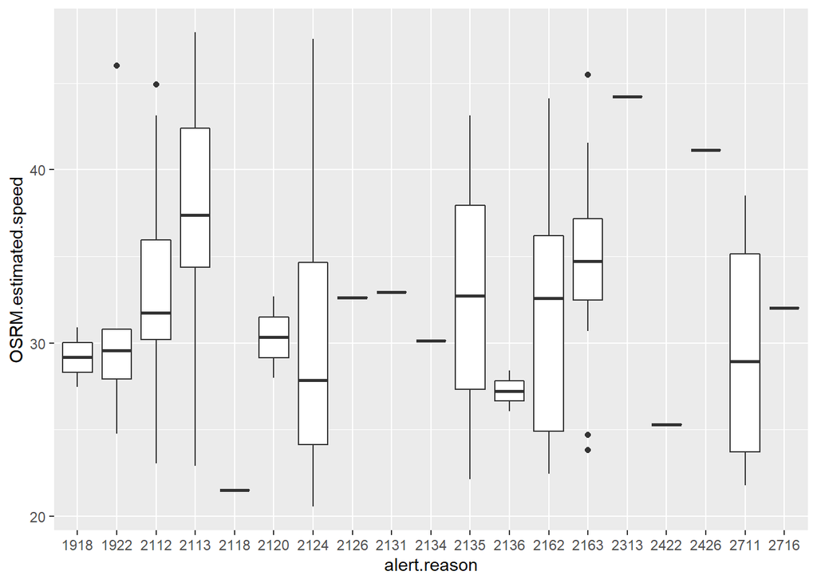

```r
data.fe.sample %>%
  ggplot(aes(x=alert.reason, y=OSRM.estimated.speed,group=alert.reason)) +
  geom_boxplot()
```

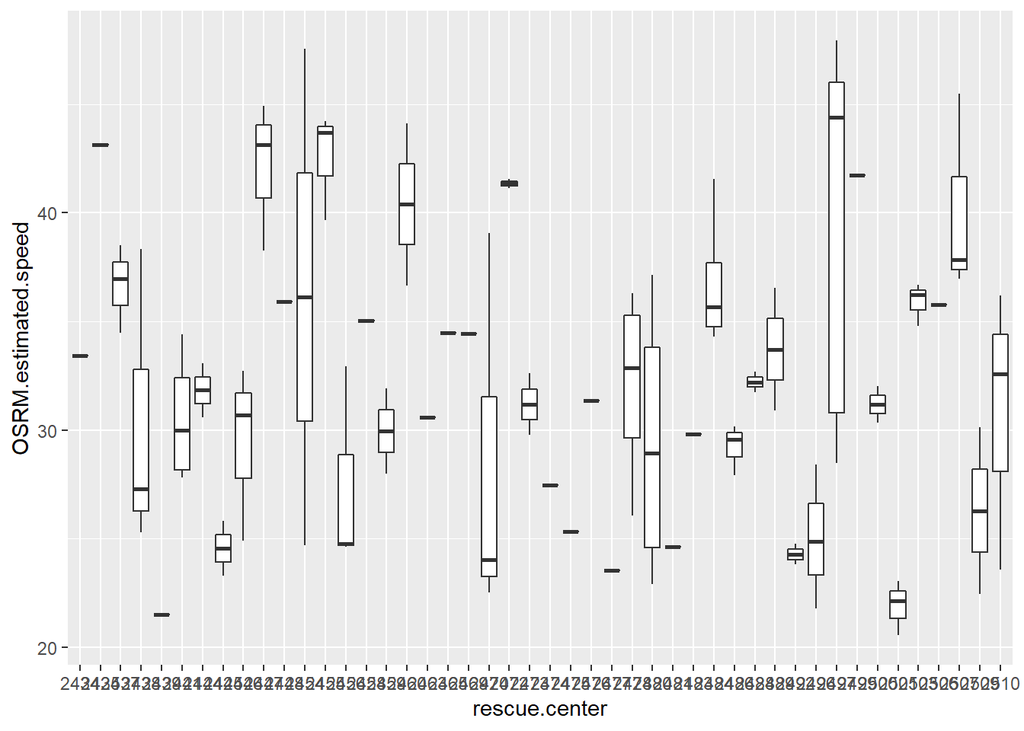

```r
data.fe.sample %>%
  ggplot(aes(x=rescue.center, y=OSRM.estimated.speed)) +
  geom_boxplot()
```

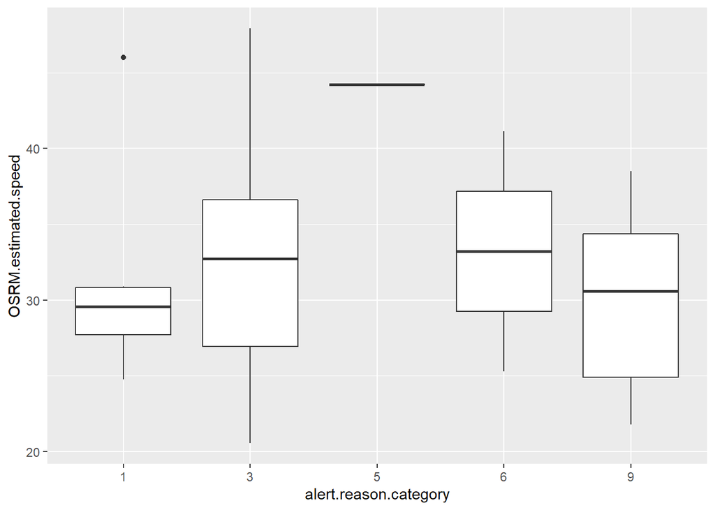

```r
data.fe.sample %>%
  ggplot(aes(x=alert.reason.category, y=OSRM.estimated.speed)) +
  geom_boxplot()
```

### 4.2 Add month, day of week

```r
data.fe$month <-month(as.Date(as.character(data.fe$date.key.selection), "%Y%m%d"))

data.fe$weekdays <-weekdays(as.Date(as.character(data.fe$date.key.selection), "%Y%m%d"))
```

Same for x_test

```r
x_test$month <-month(as.Date(as.character(x_test$date.key.selection), "%Y%m%d"))

x_test$weekdays <-weekdays(as.Date(as.character(x_test$date.key.selection), "%Y%m%d"))
```

```r
data.fe$hours <-as.hms(formatC(as.integer(data.fe$time.key.selection), big.mark = ":", big.interval = 2L))
data.fe$hours <- replace(data.fe$hours, is.na(data.fe$hours), "00:00:00")
```

Same for x_test

```r
x_test$hours <-as.hms(formatC(as.integer(x_test$time.key.selection), big.mark = ":", big.interval = 2L))
x_test$hours <- replace(x_test$hours, is.na(x_test$hours), "00:00:00")
```

```r
data.fe$hours <- substr(data.fe$hours, 1, 2)
x_test$hours <- substr(x_test$hours, 1, 2)
```

```r
table(data.fe$month)
```

```
##
##     1     2     3     4     5     6     7     8    10    11    12
## 19483 17123 18860 17661 18879 19098 19792 16327 19134 19065 19565
```

```r
prop.table(table(data.fe$month))
```

```
##
##          1          2          3          4          5          6          7
## 0.09504505 0.08353213 0.09200583 0.08615668 0.09209852 0.09316688 0.09655246
##          8         10         11         12
## 0.07964895 0.09334250 0.09300590 0.09544508
```

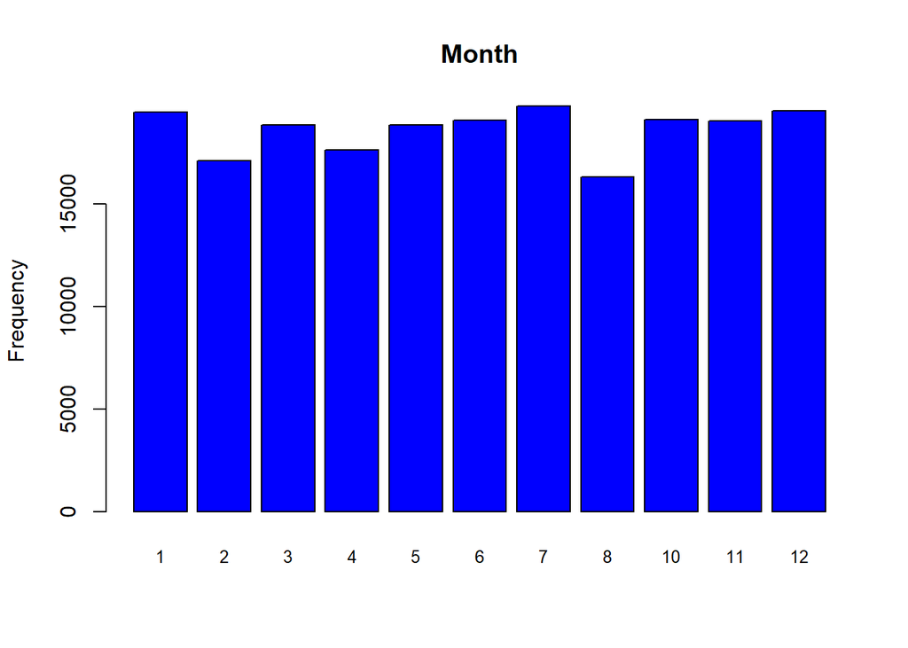

```r
barplot(table(data.fe$month),horiz = F,cex.names=0.8,col="blue",main="Month",ylab="Frequency", plot=TRUE)
```

```r
table(data.fe$weekdays)
```

```
##
## dimanche    jeudi    lundi    mardi mercredi   samedi vendredi
##    28066    29257    31000    29163    29178    28093    30230
```

```r
prop.table(table(data.fe$weekdays))
```

```
##
##  dimanche     jeudi     lundi     mardi  mercredi    samedi  vendredi
## 0.1369160 0.1427261 0.1512291 0.1422676 0.1423407 0.1370477 0.1474728
```

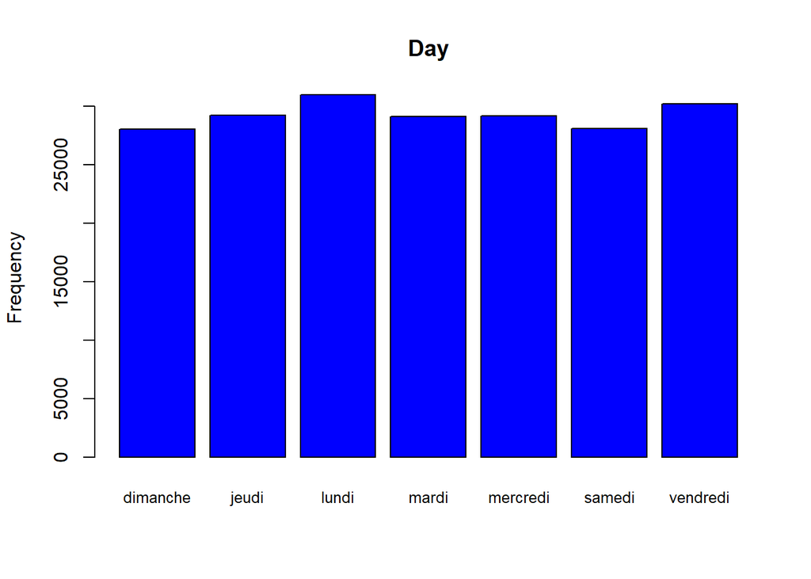

```r
barplot(table(data.fe$weekdays),horiz = F,cex.names=0.8,col="blue",main="Day",ylab="Frequency", plot=TRUE)
```

```r
table(data.fe$hours)
```

```
##
##    00    01    02    03    04    05    06    07    08    09    10    11    12
##  7420  6346  5153  4706  4142  3953  4376  5562  7596  9230  9871 10546 11326
##    13    14    15    16    17    18    19    20    21    22    23
## 11159 10737 10307 10159 10282 10684 11349 11122 10462  9767  8732
```

```r
prop.table(table(data.fe$hours))
```

```
##
##         00         01         02         03         04         05         06
## 0.03619742 0.03095806 0.02513818 0.02295755 0.02020616 0.01928415 0.02134770
##         07         08         09         10         11         12         13
## 0.02713343 0.03705601 0.04502725 0.04815427 0.05144716 0.05525228 0.05443760
##         14         15         16         17         18         19         20
## 0.05237893 0.05028124 0.04955924 0.05015928 0.05212038 0.05536449 0.05425710
##         21         22         23
## 0.05103738 0.04764692 0.04259782
```

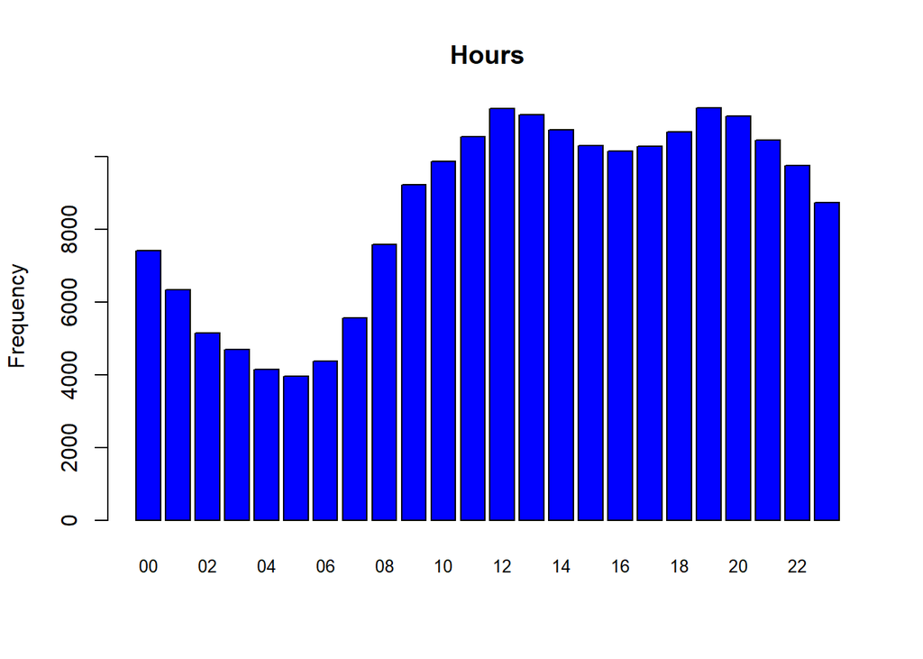

```r
barplot(table(data.fe$hours),horiz = F,cex.names=0.8,col="blue",main="Hours",ylab="Frequency", plot=TRUE)
```

We can now remove date.key.selection and time.key.selection

```r
data.fe<-data.fe[,-c(13,14)]
```

Same for x_test

```r
x_test<-x_test[,-c(13,14)]
```

Convert time and date build variables into factors

```r
data.fe$hours <- as.factor(data.fe$hours)
data.fe$weekdays <- as.factor(data.fe$weekdays)
data.fe$month <- as.factor(data.fe$month)
```

```r
x_test$hours <- as.factor(x_test$hours)
x_test$weekdays <- as.factor(x_test$weekdays)
x_test$month <- as.factor(x_test$month)
```

### 4.3 Order of the brigade

For the same event, multiple brigade can leave. It is worth to take into account that it might be a correlation between the order of the brigade to leave and the time for preparation. Once we have classify those brigade, we will be able to remove the id of the intervention.

```r
data.fe$intervention %>% as.factor() %>% str
```

```
##  Factor w/ 196480 levels "12649492","12650159",..: 111710 2131 168556 8491 173225 5521 137030 17551 143501 143369 ...
```

```r
data.fe$emergency.vehicle.selection %>% str
```

```
##  int [1:204987] 5105452 4720915 5365374 4741586 5381209 4731603 5196431 4774057 5277444 5277017 ...
```

```r
204987-196480
```

```
## [1] 8507
```

```r
x_test$intervention %>% as.factor() %>% str
```

```
##  Factor w/ 102466 levels "12649492","12650159",..: 73849 56296 64950 86532 68610 73049 784 52060 18501 92121 ...
```

Plot frequency order of id intervention.

```r
a<-data.fe %>%
        group_by(intervention)%>%
         tally()
```

```r
b<-x_test %>%
        group_by(intervention)%>%
         tally()
```

```r
a %>% setDT
a %>% str
```

```
## Classes 'data.table' and 'data.frame':   196480 obs. of  2 variables:
##  $ intervention: int  12649492 12650159 12651734 12651765 12651790 12651791 12651829 12651860 12651907 12651960 ...
##  $ n           : int  1 1 1 1 1 1 1 1 1 1 ...
```

```r
b %>% setDT
```

```r
data.fe<-merge(a,data.fe, by.x = 'intervention', by.y = 'intervention', all=FALSE)
```

```r
x_test<-merge(b,x_test, by.x = 'intervention', by.y = 'intervention', all=FALSE)
```

Rename and convert as factor

```r
data.fe$n<-data.fe$n %>% as.factor
x_test$n<-x_test$n %>% as.factor
```

Now that we have intervention frequency as factor, we can remove intervention ID

```r
data.fe<-data.fe[,-c(1)]
x_test<-x_test[,-c(1)]
```

### 4.4 GPS

We decide to remove GPS data since we have the same data.

```r
data.fe<-data.fe[,-c(18,19)]
x_test<-x_test[,-c(18,19)]
```

## 5. Correlation analysis

Update data.quanti and data.quali

```r
colnames(data.fe)
```

```
##  [1] "n"
##  [2] "emergency.vehicle.selection"
##  [3] "alert.reason.category"
##  [4] "alert.reason"
##  [5] "intervention.on.public.roads"
##  [6] "floor"
##  [7] "location.of.the.event"
##  [8] "longitude.intervention"
##  [9] "latitude.intervention"
## [10] "emergency.vehicle"
## [11] "emergency.vehicle.type"
## [12] "rescue.center"
## [13] "status.preceding.selection"
## [14] "delta.status.preceding.selection.selection"
## [15] "departed.from.its.rescue.center"
## [16] "longitude.before.departure"
## [17] "latitude.before.departure"
## [18] "OSRM.estimated.distance"
## [19] "OSRM.estimated.duration"
## [20] "delta.selection.departure"
## [21] "delta.departure.presentation"
## [22] "delta.selection.presentation"
## [23] "OSRM.estimated.speed"
## [24] "month"
## [25] "weekdays"
## [26] "hours"
```

```r
str(data.fe)
```

```
## Classes 'data.table' and 'data.frame':   204987 obs. of  26 variables:
##  $ n                                         : Factor w/ 12 levels "1","2","3","4",..: 1 1 1 1 1 1 1 1 1 1 ...
##  $ emergency.vehicle.selection               : int  4714126 4714817 4713701 4713715 4713916 4713754 4713742 4713752 4713762 4713791 ...
##  $ alert.reason.category                     : Factor w/ 9 levels "1","2","3","4",..: 1 1 3 3 3 1 1 3 1 3 ...
##  $ alert.reason                              : Factor w/ 122 levels "1911","1912",..: 6 7 60 32 60 3 4 60 3 31 ...
##  $ intervention.on.public.roads              : Factor w/ 2 levels "0","1": 1 1 1 2 1 1 2 1 2 1 ...
##  $ floor                                     : Factor w/ 20 levels "-2","-1","0",..: 8 6 10 3 4 3 3 3 3 3 ...
##  $ location.of.the.event                     : Factor w/ 210 levels "100","101","102",..: 36 21 39 48 39 65 48 1 48 49 ...
##  $ longitude.intervention                    : num  2.34 2.28 2.33 2.3 2.2 ...
##  $ latitude.intervention                     : num  48.9 48.9 48.9 48.9 48.9 ...
##  $ emergency.vehicle                         : Factor w/ 639 levels "1815","1823",..: 318 92 488 398 442 598 308 445 69 125 ...
##  $ emergency.vehicle.type                    : Factor w/ 41 levels "AR","BEAA BSPP",..: 24 24 37 37 37 15 24 37 24 8 ...
##  $ rescue.center                             : Factor w/ 79 levels "2418","2434",..: 41 3 63 15 58 5 72 27 28 6 ...
##  $ status.preceding.selection                : Factor w/ 2 levels "Disponible","RentrÃ©": 2 2 2 2 2 2 1 2 2 2 ...
##  $ delta.status.preceding.selection.selection: int  8293 16251 875 606 4693 86 7 1382 2062 968 ...
##  $ departed.from.its.rescue.center           : Factor w/ 2 levels "0","1": 2 2 2 2 2 2 1 2 2 2 ...
##  $ longitude.before.departure                : num  2.33 2.28 2.34 2.29 2.18 ...
##  $ latitude.before.departure                 : num  48.9 48.9 48.9 48.9 48.9 ...
##  $ OSRM.estimated.distance                   : num  1283 2347 1525 1812 2586 ...
##  $ OSRM.estimated.duration                   : num  214 218 173 198 280 ...
##  $ delta.selection.departure                 : int  239 47 118 149 97 113 64 120 134 94 ...
##  $ delta.departure.presentation              : int  174 376 214 268 409 678 98 187 623 181 ...
##  $ delta.selection.presentation              : int  413 423 332 417 506 791 162 307 757 275 ...
##  $ OSRM.estimated.speed                      : num  21.6 38.8 31.7 33 33.2 ...
##  $ month                                     : Factor w/ 11 levels "1","2","3","4",..: 1 1 1 1 1 1 1 1 1 1 ...
##  $ weekdays                                  : Factor w/ 7 levels "dimanche","jeudi",..: 3 3 3 3 3 3 3 3 3 3 ...
##  $ hours                                     : Factor w/ 24 levels "00","01","02",..: 4 10 1 1 2 1 1 1 1 1 ...
##  - attr(*, ".internal.selfref")=<externalptr>
```

```r
data.quanti<-data.fe[,c(23,22,19,18,17,16,14,9,8,2)]

data.quanti.y<-data.fe[,c(23,22,21,20,19,18,17,16,14,9,8,2)]

data.quali<-data.fe[,-c(23,22,21,20,19,18,17,16,14,9,8,2)]

data.quali.y<-data.fe[,-c(23,22,19,18,17,16,14,9,8,2)]

str(data.quanti)
```

```
## Classes 'data.table' and 'data.frame':   204987 obs. of  10 variables:
##  $ OSRM.estimated.speed                      : num  21.6 38.8 31.7 33 33.2 ...
##  $ delta.selection.presentation              : int  413 423 332 417 506 791 162 307 757 275 ...
##  $ OSRM.estimated.duration                   : num  214 218 173 198 280 ...
##  $ OSRM.estimated.distance                   : num  1283 2347 1525 1812 2586 ...
##  $ latitude.before.departure                 : num  48.9 48.9 48.9 48.9 48.9 ...
##  $ longitude.before.departure                : num  2.33 2.28 2.34 2.29 2.18 ...
##  $ delta.status.preceding.selection.selection: int  8293 16251 875 606 4693 86 7 1382 2062 968 ...
##  $ latitude.intervention                     : num  48.9 48.9 48.9 48.9 48.9 ...
##  $ longitude.intervention                    : num  2.34 2.28 2.33 2.3 2.2 ...
##  $ emergency.vehicle.selection               : int  4714126 4714817 4713701 4713715 4713916 4713754 4713742 4713752 4713762 4713791 ...
##  - attr(*, ".internal.selfref")=<externalptr>
```

```r
str(data.quanti.y)
```

```
## Classes 'data.table' and 'data.frame':   204987 obs. of  12 variables:
##  $ OSRM.estimated.speed                      : num  21.6 38.8 31.7 33 33.2 ...
##  $ delta.selection.presentation              : int  413 423 332 417 506 791 162 307 757 275 ...
##  $ delta.departure.presentation              : int  174 376 214 268 409 678 98 187 623 181 ...
##  $ delta.selection.departure                 : int  239 47 118 149 97 113 64 120 134 94 ...
##  $ OSRM.estimated.duration                   : num  214 218 173 198 280 ...
##  $ OSRM.estimated.distance                   : num  1283 2347 1525 1812 2586 ...
##  $ latitude.before.departure                 : num  48.9 48.9 48.9 48.9 48.9 ...
##  $ longitude.before.departure                : num  2.33 2.28 2.34 2.29 2.18 ...
##  $ delta.status.preceding.selection.selection: int  8293 16251 875 606 4693 86 7 1382 2062 968 ...
##  $ latitude.intervention                     : num  48.9 48.9 48.9 48.9 48.9 ...
##  $ longitude.intervention                    : num  2.34 2.28 2.33 2.3 2.2 ...
##  $ emergency.vehicle.selection               : int  4714126 4714817 4713701 4713715 4713916 4713754 4713742 4713752 4713762 4713791 ...
##  - attr(*, ".internal.selfref")=<externalptr>
```

```r
str(data.quali)
```

```
## Classes 'data.table' and 'data.frame':   204987 obs. of  14 variables:
##  $ n                              : Factor w/ 12 levels "1","2","3","4",..: 1 1 1 1 1 1 1 1 1 1 ...
##  $ alert.reason.category          : Factor w/ 9 levels "1","2","3","4",..: 1 1 3 3 3 1 1 3 1 3 ...
##  $ alert.reason                   : Factor w/ 122 levels "1911","1912",..: 6 7 60 32 60 3 4 60 3 31 ...
##  $ intervention.on.public.roads   : Factor w/ 2 levels "0","1": 1 1 1 2 1 1 2 1 2 1 ...
##  $ floor                          : Factor w/ 20 levels "-2","-1","0",..: 8 6 10 3 4 3 3 3 3 3 ...
##  $ location.of.the.event          : Factor w/ 210 levels "100","101","102",..: 36 21 39 48 39 65 48 1 48 49 ...
##  $ emergency.vehicle              : Factor w/ 639 levels "1815","1823",..: 318 92 488 398 442 598 308 445 69 125 ...
##  $ emergency.vehicle.type         : Factor w/ 41 levels "AR","BEAA BSPP",..: 24 24 37 37 37 15 24 37 24 8 ...
##  $ rescue.center                  : Factor w/ 79 levels "2418","2434",..: 41 3 63 15 58 5 72 27 28 6 ...
##  $ status.preceding.selection     : Factor w/ 2 levels "Disponible","RentrÃ©": 2 2 2 2 2 2 1 2 2 2 ...
##  $ departed.from.its.rescue.center: Factor w/ 2 levels "0","1": 2 2 2 2 2 2 1 2 2 2 ...
##  $ month                          : Factor w/ 11 levels "1","2","3","4",..: 1 1 1 1 1 1 1 1 1 1 ...
##  $ weekdays                       : Factor w/ 7 levels "dimanche","jeudi",..: 3 3 3 3 3 3 3 3 3 3 ...
##  $ hours                          : Factor w/ 24 levels "00","01","02",..: 4 10 1 1 2 1 1 1 1 1 ...
##  - attr(*, ".internal.selfref")=<externalptr>
```

```r
str(data.quali.y)
```

```
## Classes 'data.table' and 'data.frame':   204987 obs. of  16 variables:
##  $ n                              : Factor w/ 12 levels "1","2","3","4",..: 1 1 1 1 1 1 1 1 1 1 ...
##  $ alert.reason.category          : Factor w/ 9 levels "1","2","3","4",..: 1 1 3 3 3 1 1 3 1 3 ...
##  $ alert.reason                   : Factor w/ 122 levels "1911","1912",..: 6 7 60 32 60 3 4 60 3 31 ...
##  $ intervention.on.public.roads   : Factor w/ 2 levels "0","1": 1 1 1 2 1 1 2 1 2 1 ...
##  $ floor                          : Factor w/ 20 levels "-2","-1","0",..: 8 6 10 3 4 3 3 3 3 3 ...
##  $ location.of.the.event          : Factor w/ 210 levels "100","101","102",..: 36 21 39 48 39 65 48 1 48 49 ...
##  $ emergency.vehicle              : Factor w/ 639 levels "1815","1823",..: 318 92 488 398 442 598 308 445 69 125 ...
##  $ emergency.vehicle.type         : Factor w/ 41 levels "AR","BEAA BSPP",..: 24 24 37 37 37 15 24 37 24 8 ...
##  $ rescue.center                  : Factor w/ 79 levels "2418","2434",..: 41 3 63 15 58 5 72 27 28 6 ...
##  $ status.preceding.selection     : Factor w/ 2 levels "Disponible","RentrÃ©": 2 2 2 2 2 2 1 2 2 2 ...
##  $ departed.from.its.rescue.center: Factor w/ 2 levels "0","1": 2 2 2 2 2 2 1 2 2 2 ...
##  $ delta.selection.departure      : int  239 47 118 149 97 113 64 120 134 94 ...
##  $ delta.departure.presentation   : int  174 376 214 268 409 678 98 187 623 181 ...
##  $ month                          : Factor w/ 11 levels "1","2","3","4",..: 1 1 1 1 1 1 1 1 1 1 ...
##  $ weekdays                       : Factor w/ 7 levels "dimanche","jeudi",..: 3 3 3 3 3 3 3 3 3 3 ...
##  $ hours                          : Factor w/ 24 levels "00","01","02",..: 4 10 1 1 2 1 1 1 1 1 ...
##  - attr(*, ".internal.selfref")=<externalptr>
```

After engineering new features and before starting the modeling, we have to visualize the relations between our parameters using a correlation matrix. For this, we need to change all the factor features into a numerical format. The visualization uses the corrplot function from the eponymous package. Corrplot gives us great flexibility in manipulating the style of our plot.

What we see below, are the color-coded correlation coefficients for each combination of two features. In simplest terms: this shows whether two features are connected so that one changes with a predictable trend if you change the other. The closer this coefficient is to zero the weaker is the correlation. Both 1 and -1 are the ideal cases of perfect correlation and anti-correlation (dark blue and dark red in the plots below).

Here, we are of course interested if and how strongly our correlate with the ys. But we also want to know whether our potential predictors are correlated among each other, so that we can reduce the colinearity in our data set and improve the robustness of our prediction.

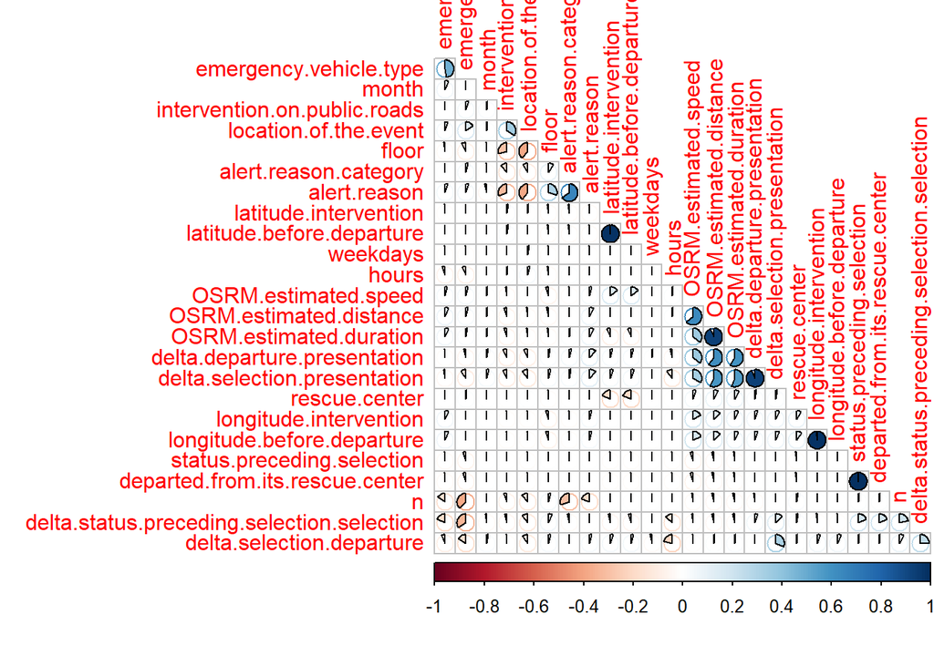

```r
data.fe %>%
  select(-emergency.vehicle.selection) %>%
  mutate(n = as.integer(n),
         alert.reason = as.integer(alert.reason),
         floor = as.integer(floor),
         emergency.vehicle = as.integer(emergency.vehicle),
         rescue.center = as.integer(rescue.center),
         delta.selection.presentation = as.integer(delta.selection.presentation),
         month = as.integer(month),
         hours = as.integer(hours),
        weekdays = as.integer(weekdays),
         alert.reason.category = as.integer(alert.reason.category),
         intervention.on.public.roads = as.integer(intervention.on.public.roads),
         location.of.the.event = as.integer(location.of.the.event),
         emergency.vehicle.type = as.integer(emergency.vehicle.type),
         status.preceding.selection = as.integer(status.preceding.selection),
          departed.from.its.rescue.center = as.integer(departed.from.its.rescue.center))%>%

  cor(use="complete.obs", method = "spearman") %>%
  corrplot(type="lower", method="pie",order="hclust",
         diag=FALSE)
```

Add coefficients

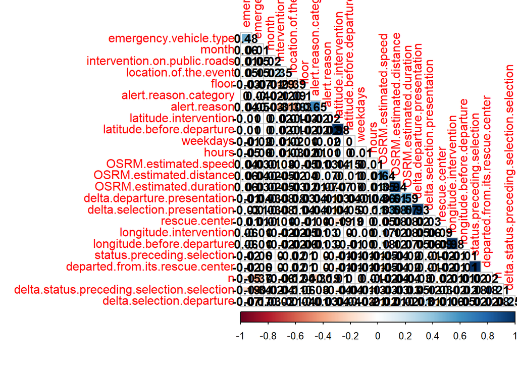

```r
data.fe %>%
  select(-emergency.vehicle.selection) %>%
  mutate(n = as.integer(n),
         alert.reason = as.integer(alert.reason),
         floor = as.integer(floor),
         emergency.vehicle = as.integer(emergency.vehicle),
         rescue.center = as.integer(rescue.center),
         delta.selection.presentation = as.integer(delta.selection.presentation),
         month = as.integer(month),
         hours = as.integer(hours),
        weekdays = as.integer(weekdays),
         alert.reason.category = as.integer(alert.reason.category),
         intervention.on.public.roads = as.integer(intervention.on.public.roads),
         location.of.the.event = as.integer(location.of.the.event),
         emergency.vehicle.type = as.integer(emergency.vehicle.type),
         status.preceding.selection = as.integer(status.preceding.selection),
          departed.from.its.rescue.center = as.integer(departed.from.its.rescue.center))%>%

  cor(use="complete.obs", method = "spearman") %>%
  corrplot(type="lower", method="square",order="hclust",
         addCoef.col = "black", diag=FALSE)
```

We find :

- Alert reason is correlated to alert reason.category (0,65).
- OSRM estimated speed and OSRM distance are correlated (this is quite normal). We decide to keep the 2 features.
- Status departure before selection and departed from its rescue center are perfectly correlated. We remove status departure before selection.
- Longitude.before.departure and longitude.intervention are highly correlated. We can remove longitude.before.departure
- Latitude.before.departure and lat.intervention are highly correlated. We can remove lat.before.departure
- Except for ORSM features, there is no high correlated feature.

```r
data.fe<-data.fe[,-c("alert.reason","status.preceding.selection","longitude.before.departure","latitude.before.departure")]
```

```r
x_test<-x_test[,-c("alert.reason","status.preceding.selection","longitude.before.departure","latitude.before.departure")]
```

## 6. Boosted Tree with XGB

Boosted Tree aka XGBoost. XGBoost is a well-known and efficient open source implementation of the improved gradient tree algorithm.  
Gradient boosting is a supervised learning algorithm, which attempts to accurately predict a target variable by combining estimates from a simpler and weaker set of models. GBoost reduces a regularized objective function (L1 and L2) that combines a convex loss function (based on the difference between predicted and target outputs) and a penalty condition for model complexity (in other words, regression tree functions). Training continues iteratively, adding new trees that predict residuals or errors from previous trees that are then combined with the previous trees to make the final prediction.

In other words we are building a tree and looks which value is predicted poorly and assign to it higher weigh in our prediction.

Let us build and predict our model with 100 maximum number of boosting iterations.

### 6.1 Sample

```r
data.fe %>% str
```

```
## Classes 'data.table' and 'data.frame':   204987 obs. of  22 variables:
##  $ n                                         : Factor w/ 12 levels "1","2","3","4",..: 1 1 1 1 1 1 1 1 1 1 ...
##  $ emergency.vehicle.selection               : int  4714126 4714817 4713701 4713715 4713916 4713754 4713742 4713752 4713762 4713791 ...
##  $ alert.reason.category                     : Factor w/ 9 levels "1","2","3","4",..: 1 1 3 3 3 1 1 3 1 3 ...
##  $ intervention.on.public.roads              : Factor w/ 2 levels "0","1": 1 1 1 2 1 1 2 1 2 1 ...
##  $ floor                                     : Factor w/ 20 levels "-2","-1","0",..: 8 6 10 3 4 3 3 3 3 3 ...
##  $ location.of.the.event                     : Factor w/ 210 levels "100","101","102",..: 36 21 39 48 39 65 48 1 48 49 ...
##  $ longitude.intervention                    : num  2.34 2.28 2.33 2.3 2.2 ...
##  $ latitude.intervention                     : num  48.9 48.9 48.9 48.9 48.9 ...
##  $ emergency.vehicle                         : Factor w/ 639 levels "1815","1823",..: 318 92 488 398 442 598 308 445 69 125 ...
##  $ emergency.vehicle.type                    : Factor w/ 41 levels "AR","BEAA BSPP",..: 24 24 37 37 37 15 24 37 24 8 ...
##  $ rescue.center                             : Factor w/ 79 levels "2418","2434",..: 41 3 63 15 58 5 72 27 28 6 ...
##  $ delta.status.preceding.selection.selection: int  8293 16251 875 606 4693 86 7 1382 2062 968 ...
##  $ departed.from.its.rescue.center           : Factor w/ 2 levels "0","1": 2 2 2 2 2 2 1 2 2 2 ...
##  $ OSRM.estimated.distance                   : num  1283 2347 1525 1812 2586 ...
##  $ OSRM.estimated.duration                   : num  214 218 173 198 280 ...
##  $ delta.selection.departure                 : int  239 47 118 149 97 113 64 120 134 94 ...
##  $ delta.departure.presentation              : int  174 376 214 268 409 678 98 187 623 181 ...
##  $ delta.selection.presentation              : int  413 423 332 417 506 791 162 307 757 275 ...
##  $ OSRM.estimated.speed                      : num  21.6 38.8 31.7 33 33.2 ...
##  $ month                                     : Factor w/ 11 levels "1","2","3","4",..: 1 1 1 1 1 1 1 1 1 1 ...
##  $ weekdays                                  : Factor w/ 7 levels "dimanche","jeudi",..: 3 3 3 3 3 3 3 3 3 3 ...
##  $ hours                                     : Factor w/ 24 levels "00","01","02",..: 4 10 1 1 2 1 1 1 1 1 ...
##  - attr(*, ".internal.selfref")=<externalptr>
```

Store final dataset

```r
dataset<-data.fe
```

Sample data

```r
set.seed(123)
n_train <- (0.8 * nrow(dataset))
train_indices <- sample(1:nrow(dataset), n_train)
trainset <- dataset[train_indices, ]
testset <- dataset[-train_indices, ]
```

### 6.2 Yo : Selection - Departure

```r
trainset %>% head
```

```
##    n emergency.vehicle.selection alert.reason.category
## 1: 1                     5387610                     3
## 2: 1                     5410147                     3
## 3: 1                     5167483                     3
## 4: 1                     5132649                     3
## 5: 3                     5315418                     1
## 6: 1                     5058200                     3
##    intervention.on.public.roads floor location.of.the.event
## 1:                            0     0                   136
## 2:                            0     0                   107
## 3:                            1     0                   228
## 4:                            1     0                   149
## 5:                            0     2                   140
## 6:                            1     0                   148
##    longitude.intervention latitude.intervention emergency.vehicle
```

[output cut: 41 more lines]

Store only y0 target value

```r
trainset0_y0<-dataset[train_indices,delta.selection.departure]
trainset0<-trainset[,-c("delta.selection.departure","delta.departure.presentation","delta.selection.presentation")]
testset0_y0<-dataset[-train_indices,delta.selection.departure]
testset0<-testset[,-c("delta.selection.departure","delta.departure.presentation","delta.selection.presentation")]
```

```r
trainset$delta.selection.departure %>% head
```

```
## [1] 166 156  65 143 126 126
```

```r
dataset[train_indices,delta.selection.departure] %>% head
```

```
## [1] 166 156  65 143 126 126
```

Create one-hot matrix for cat variable. with sparse-matrix

```r
sparse_matrix <- sparse.model.matrix( ~ ., data = trainset0)[,-1]
```

Store into xgb Matrix

```r
dtrain1 <- xgb.DMatrix(sparse_matrix,label = trainset$delta.selection.departure)
```

Set parameters for our xgb tree

```r
xgb_params <- list(colsample_bytree = 0.7, #variables per tree
                   subsample = 0.7, #data subset per tree
                   booster = "gbtree",
                   max_depth = 5, #tree levels
                   eta = 0.3, #shrinkage
                   eval_metric = "rmse",
                   objective = "reg:linear"
                   )
```

train our model

```r
set.seed(4321)
gb_0_dt <- xgb.train(params = xgb_params,
                   data = dtrain1,
                   print_every_n = 100,
                   nrounds = 100)
```

```
## [01:26:25] WARNING: amalgamation/../src/objective/regression_obj.cu:174: reg:linear is now deprecated in favor of reg:squarederror.
```

Plot the 30 first important features in our model

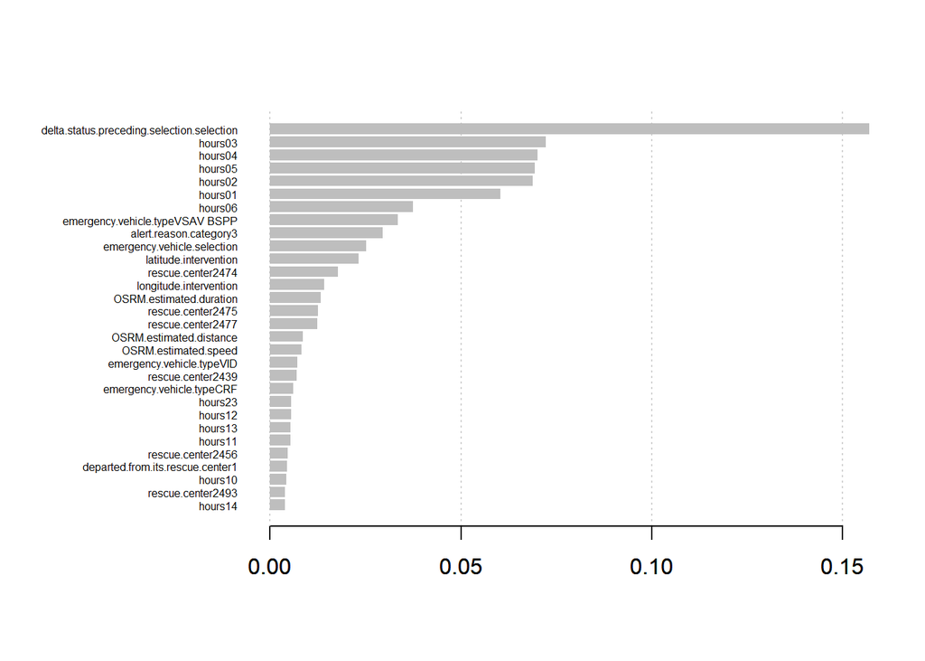

```r
importance_matrix <- xgb.importance(model = gb_0_dt)
xgb.plot.importance(importance_matrix[1:30,])
```

We find : - Delta statut preceding selection - Hours - Lat intervention - Long internvetion - emergency vehicule type VSAV$VD (group is or not) - ORSRM data - Rescue center 2474,77,75,2439 (group is or not) - Alert-reason-cat-03 -departed from its rescue center1

Predict with testset0

```r
sparse_matrix2 <- sparse.model.matrix( ~ ., data =testset0 )[,-1]
```

Store into xgb Matrix

```r
dtest <- xgb.DMatrix(sparse_matrix2,label=testset$delta.selection.departure)
```

Predict

```r
pred_xgboost_y0 <- predict(gb_0_dt,dtest)
```

```r
pred_xgboost_y0 %>% head
```

```
## [1] 140.30222  96.39616 154.99208 115.06355  85.18041 126.75983
```

```r
testset$delta.selection.departure %>% head
```

```
## [1]  47 149  97 113 124 145
```

Compute MSE, MAE, R2

```r
postResample(pred = pred_xgboost_y0, obs = testset$delta.selection.departure)
```

```
##       RMSE   Rsquared        MAE
## 46.4920917  0.2753537 34.1598139
```

### 6.3 Y1 : Departure - Presentation

Store only y1 target value

```r
trainset1_y1<-trainset$delta.departure.presentation
trainset1<-trainset[,-c("delta.selection.departure","delta.selection.presentation","delta.departure.presentation")]
testset1_y1<-testset$delta.departure.presentation
testset1<-testset[,-c("delta.selection.departure","delta.selection.presentation","delta.departure.presentation")]
```

Create one-hot matrix for cat variable. with sparse-matrix

```r
sparse_matrix <- sparse.model.matrix( ~ ., data = trainset1)[,-1]
```

Store into xgb Matrix

```r
dtrain2 <- xgb.DMatrix(sparse_matrix,label = trainset$delta.departure.presentation)
```

Set parameters for our xgb tree

```r
xgb_params <- list(colsample_bytree = 0.5, #variables per tree
                   subsample = 0.5, #data subset per tree
                   booster = "gbtree",
                   max_depth = 3, #tree levels
                   eta = 0.3, #shrinkage
                   eval_metric = "rmse",
                   objective = "reg:linear",
                   seed = 4321
                   )
```

train our model

```r
set.seed(4321)
gb_1_dt <- xgb.train(params = xgb_params,
                   data = dtrain2,
                   print_every_n = 100,
                   nrounds = 100)
```

```
## [01:26:38] WARNING: amalgamation/../src/objective/regression_obj.cu:174: reg:linear is now deprecated in favor of reg:squarederror.
```

Plot the 30 first important features in our model

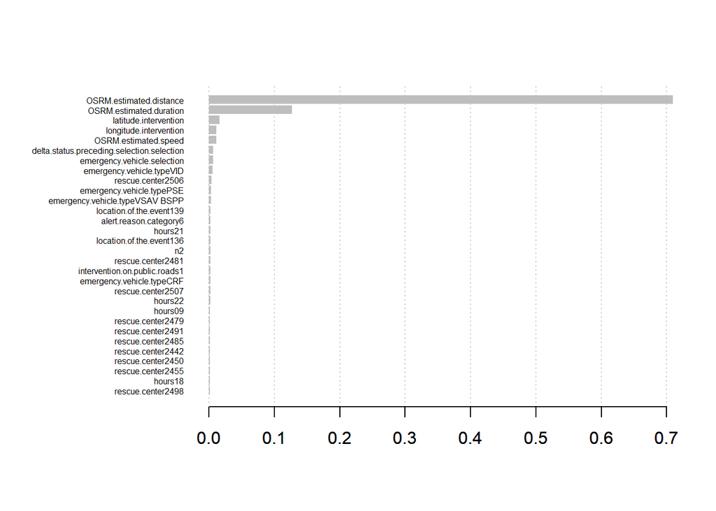

```r
importance_matrix <- xgb.importance(model = gb_1_dt)
xgb.plot.importance(importance_matrix[1:30,])
```

We find : - OSRM data - Lat intervention - Long internvetion - statut.preceding-selection - emergency vehicule type VSAV$VD (group is or not)

Predict

```r
sparse_matrix2 <- sparse.model.matrix( ~ ., data =testset1 )[,-1]
```

Store into xgb Matrix

```r
dtest <- xgb.DMatrix(sparse_matrix2,label=testset$delta.departure.presentation)
```

Predict

```r
pred_xgboost_y1 <- predict(gb_1_dt,dtest)
```

```r
pred_xgboost_y1 %>% head
```

```
## [1] 415.4552 306.6591 403.4247 377.4039 363.4391 397.6378
```

```r
testset$delta.departure.presentation %>% head
```

```
## [1] 376 268 409 678 432 236
```

```r
postResample(pred = pred_xgboost_y1, obs = testset$delta.departure.presentation)
```

```
##        RMSE    Rsquared         MAE
## 125.2175578   0.4038202  89.9848882
```

### 6.4 Ys : Compute global

```r
pred_xgboost_ys=pred_xgboost_y0+pred_xgboost_y1
pred_xgboost=data.frame(pred_xgboost_y0,pred_xgboost_y1,pred_xgboost_ys)

pred_xgboost %>% head
```

```
##   pred_xgboost_y0 pred_xgboost_y1 pred_xgboost_ys
## 1       140.30222        415.4552        555.7574
## 2        96.39616        306.6591        403.0553
## 3       154.99208        403.4247        558.4167
## 4       115.06355        377.4039        492.4674
## 5        85.18041        363.4391        448.6195
## 6       126.75983        397.6378        524.3976
```

```r
testset$delta.selection.presentation %>% head
```

```
## [1] 423 417 506 791 556 381
```

```r
postResample(pred = pred_xgboost_ys, obs = testset$delta.departure.presentation)
```

```
##       RMSE   Rsquared        MAE
## 186.759072   0.384372 165.226319
```

No too bad accuracy !

### 6.5 Use feature importance to create group for factor variables for futur models

For Y0

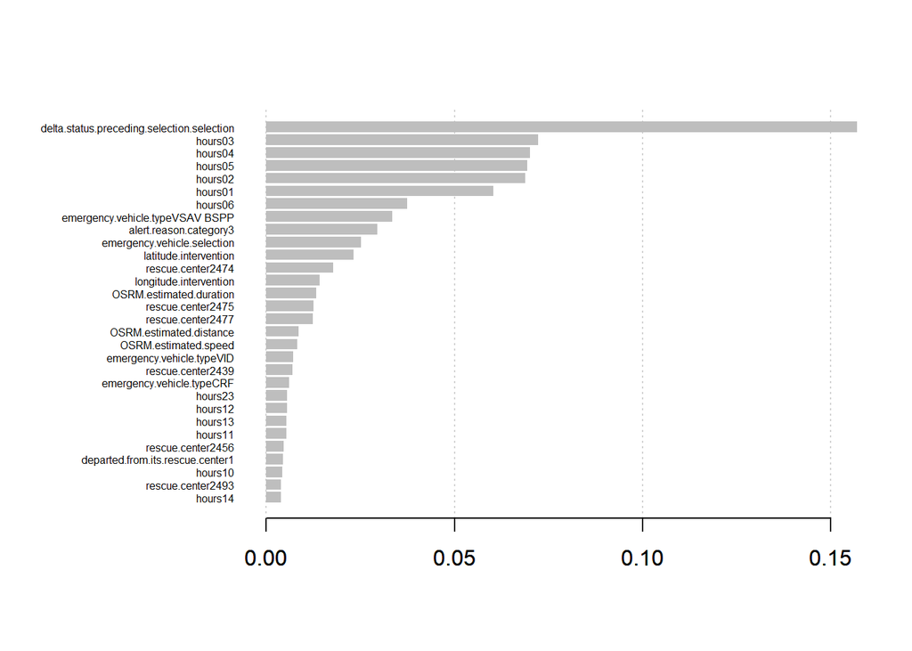

```r
importance_matrix_y0 <- xgb.importance(model = gb_0_dt)
xgb.plot.importance(importance_matrix_y0[1:30,])
```

```r
importance_matrix_y0[1:30,]
```

```
##                                        Feature        Gain        Cover
##  1: delta.status.preceding.selection.selection 0.156960966 0.0353014695
##  2:                                    hours03 0.072181643 0.0134732246
##  3:                                    hours04 0.070018506 0.0130817159
##  4:                                    hours05 0.069297197 0.0128591216
##  5:                                    hours02 0.068886010 0.0132399501
##  6:                                    hours01 0.060420820 0.0125660520
##  7:                                    hours06 0.037428929 0.0131693354
##  8:            emergency.vehicle.typeVSAV BSPP 0.033491678 0.0108941036
##  9:                     alert.reason.category3 0.029556868 0.0038505879
## 10:                emergency.vehicle.selection 0.025238333 0.0288528568
## 11:                      latitude.intervention 0.023163862 0.0152647111
## 12:                          rescue.center2474 0.017850762 0.0104794051
## 13:                     longitude.intervention 0.014201064 0.0083155053
## 14:                    OSRM.estimated.duration 0.013281196 0.0141529769
```

[output cut: 49 more lines]

We find : - Delta status preceding selection - Hours - Lat intervention - Long intervention - emergency vehicle type VSAV$VD (group is or not) - emergency.vehicle.typePSE - emergency.vehicle.typeVID - emergency.vehicle.typeCRF - emergency.vehicle.typeFNPC - ORSRM data - Rescue center 2474,2477,2475,2439, 2435,2464, 2488, 2493(group is or not) - Alert-reason-cat-03 -2 -departed from its rescue center1

We regroup the types of emergency vehicle, the rescue centers and the alert reason category

```r
trainset0.regroup <- trainset0
testset0.regroup <- testset0

trainset0.regroup = trainset0.regroup %>%
    mutate(emergency.vehicle.type.regroup = case_when(emergency.vehicle.type == "VSAV BSPP" ~  1,
                                  emergency.vehicle.type =="PSE" ~  1,
                                  emergency.vehicle.type == "VID" ~  1,
                                  emergency.vehicle.type == "CRF" ~  1,
                                  emergency.vehicle.type == "FNPC" ~  1,
                                  TRUE ~ 0))
trainset0.regroup = trainset0.regroup %>%
    mutate(rescue.center.regroup = case_when(rescue.center == "2474" ~  1,
                                  rescue.center =="2477" ~  1,
                                  rescue.center == "2475" ~  1,
                                  rescue.center == "2439" ~  1,
                                  rescue.center == "2435" ~  1,
                                  rescue.center == "2464" ~  1,
                                  rescue.center == "2488" ~  1,
                                  rescue.center == "2493" ~  1,
                                  TRUE ~ 0))


testset0.regroup = testset0.regroup %>%
    mutate(emergency.vehicle.type.regroup = case_when(emergency.vehicle.type == "VSAV BSPP" ~  1,
                                  emergency.vehicle.type =="PSE" ~  1,
                                  emergency.vehicle.type == "VID" ~  1,
                                  emergency.vehicle.type == "CRF" ~  1,
                                  emergency.vehicle.type == "FNPC" ~  1,
                                  TRUE ~ 0))
testset0.regroup = testset0.regroup  %>%
    mutate(rescue.center.regroup = case_when(rescue.center == "2474" ~  1,
                                  rescue.center =="2477" ~  1,
                                  rescue.center == "2475" ~  1,
                                  rescue.center == "2439" ~  1,
                                  rescue.center == "2435" ~  1,
                                  rescue.center == "2464" ~  1,
                                  rescue.center == "2488" ~  1,
                                  rescue.center == "2493" ~  1,
                                  TRUE ~ 0))
```

Drop not-important features in trainset0

```r
trainset0.regroup$rescue.center<-NULL
trainset0.regroup$n<-NULL
trainset0.regroup$emergency.vehicle.type<-NULL
trainset0.regroup$floor<-NULL
trainset0.regroup$emergency.vehicle<-NULL
trainset0.regroup$weekdays<-NULL
trainset0.regroup$intervention.on.public.roads<-NULL
trainset0.regroup$location.of.the.event<-NULL
trainset0.regroup$month<-NULL
```

```r
testset0.regroup$rescue.center<-NULL
testset0.regroup$emergency.vehicle.type<-NULL

testset0.regroup$n<-NULL
testset0.regroup$floor<-NULL
testset0.regroup$emergency.vehicle<-NULL
testset0.regroup$weekdays<-NULL
testset0.regroup$intervention.on.public.roads<-NULL
testset0.regroup$location.of.the.event<-NULL
testset0.regroup$month<-NULL
```

Same for x_test

```r
x_test0.regroup <- x_test

x_test0.regroup = x_test0.regroup %>%
    mutate(emergency.vehicle.type.regroup = case_when(emergency.vehicle.type == "VSAV BSPP" ~  1,
                                  emergency.vehicle.type =="PSE" ~  1,
                                  emergency.vehicle.type == "VID" ~  1,
                                  emergency.vehicle.type == "CRF" ~  1,
                                  emergency.vehicle.type == "FNPC" ~  1,
                                  TRUE ~ 0))
x_test0.regroup = x_test0.regroup %>%
    mutate(rescue.center.regroup = case_when(rescue.center == "2474" ~  1,
                                  rescue.center =="2477" ~  1,
                                  rescue.center == "2475" ~  1,
                                  rescue.center == "2439" ~  1,
                                  rescue.center == "2435" ~  1,
                                  rescue.center == "2464" ~  1,
                                  rescue.center == "2488" ~  1,
                                  rescue.center == "2493" ~  1,
                                  TRUE ~ 0))
```

```r
x_test0.regroup$rescue.center<-NULL
x_test0.regroup$emergency.vehicle.type<-NULL

x_test0.regroup$n<-NULL
x_test0.regroup$floor<-NULL
x_test0.regroup$emergency.vehicle<-NULL
x_test0.regroup$weekdays<-NULL
x_test0.regroup$intervention.on.public.roads<-NULL
x_test0.regroup$location.of.the.event<-NULL
x_test0.regroup$month<-NULL
```

For Y1

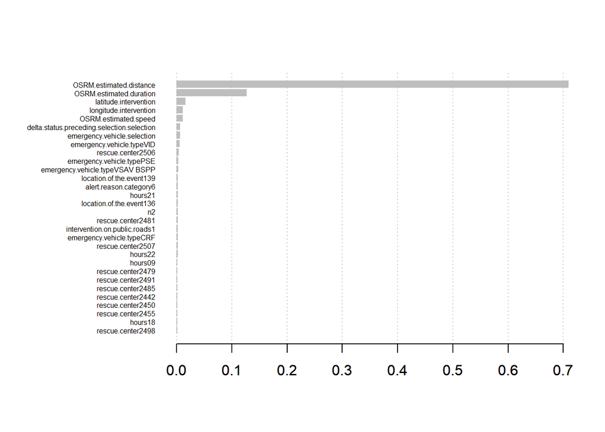

```r
importance_matrix_y1 <- xgb.importance(model = gb_1_dt)
xgb.plot.importance(importance_matrix_y1[1:30,])
```

```r
importance_matrix_y1[1:30,]
```

```
##                                        Feature        Gain       Cover
##  1:                    OSRM.estimated.distance 0.709412629 0.058331801
##  2:                    OSRM.estimated.duration 0.126576169 0.065559114
##  3:                      latitude.intervention 0.015988622 0.037607944
##  4:                     longitude.intervention 0.011153806 0.027810403
##  5:                       OSRM.estimated.speed 0.010997592 0.016156794
##  6: delta.status.preceding.selection.selection 0.006750294 0.011458927
##  7:                emergency.vehicle.selection 0.006270702 0.030779022
##  8:                  emergency.vehicle.typeVID 0.005569648 0.009361946
##  9:                          rescue.center2506 0.004225152 0.015055506
## 10:                  emergency.vehicle.typePSE 0.003136839 0.012488449
## 11:            emergency.vehicle.typeVSAV BSPP 0.003132041 0.003476509
## 12:                   location.of.the.event139 0.002581180 0.013239570
## 13:                     alert.reason.category6 0.002392792 0.012834226
## 14:                                    hours21 0.002281380 0.011122909
```

[output cut: 49 more lines]

We find : - OSRM data - Lat intervention - Long intervention - status.preceding-selection - emergency.vehicle.typeVID - emergency.vehicle.typePSE - emergency.vehicle.typeCRF - rescue.center2506, 2507, 2485, 2481, 2498, 2500 - emergency.vehicle.typeVSAV BSPP - emergency.vehicle.typeFPT BSPP - alert.reason.category6 - location.of.the.event139, 136, 259

```r
trainset1.regroup <- trainset1
testset1.regroup <- testset1

trainset1.regroup = trainset1.regroup %>%
    mutate(emergency.vehicle.type.regroup = case_when(emergency.vehicle.type == "VSAV BSPP" ~  1,
                                  emergency.vehicle.type =="FPT BSPP" ~  1,
                                  emergency.vehicle.type == "VID" ~  1,
                                  emergency.vehicle.type == "CRF" ~  1,
                                  emergency.vehicle.type == "PSE" ~  1,
                                  TRUE ~ 0))

trainset1.regroup = trainset1.regroup %>%
    mutate(rescue.center.regroup = case_when(rescue.center == "2506" ~  1,
                                  rescue.center =="2507" ~  1,
                                  rescue.center == "2485" ~  1,
                                  rescue.center == "2481" ~  1,
                                  rescue.center == "2498" ~  1,
                                  rescue.center == "2500" ~  1,
                                  TRUE ~ 0))
trainset1.regroup = trainset1.regroup %>%
    mutate(location.of.the.event.regroup = case_when(location.of.the.event == "2506" ~  1,
                                  location.of.the.event =="139" ~  1,
                                  location.of.the.event == "136" ~  1,
                                  rescue.center == "259" ~  1,
                                  TRUE ~ 0))

testset1.regroup = testset1.regroup %>%
    mutate(emergency.vehicle.type.regroup = case_when(emergency.vehicle.type == "VSAV BSPP" ~  1,
                                  emergency.vehicle.type =="FPT BSPP" ~  1,
                                  emergency.vehicle.type == "VID" ~  1,
                                  emergency.vehicle.type == "CRF" ~  1,
                                  emergency.vehicle.type == "PSE" ~  1,
                                  TRUE ~ 0))

testset1.regroup = testset1.regroup %>%
    mutate(rescue.center.regroup = case_when(rescue.center == "2506" ~  1,
                                  rescue.center =="2507" ~  1,
                                  rescue.center == "2485" ~  1,
                                  rescue.center == "2481" ~  1,
                                  rescue.center == "2498" ~  1,
                                  rescue.center == "2500" ~  1,
                                  TRUE ~ 0))
testset1.regroup = testset1.regroup%>%
    mutate(location.of.the.event.regroup = case_when(location.of.the.event == "2506" ~  1,
                                  location.of.the.event =="139" ~  1,
                                  location.of.the.event == "136" ~  1,
                                  rescue.center == "259" ~  1,
                                  TRUE ~ 0))
```

Drop not important features

```r
trainset1.regroup$rescue.center<-NULL
trainset1.regroup$emergency.vehicle.type<-NULL
trainset1.regroup$location.of.the.event<-NULL
trainset1.regroup$emergency.vehicle<-NULL
trainset1.regroup$departed.from.its.rescue.center<-NULL
```

```r
testset1.regroup$rescue.center<-NULL
testset1.regroup$emergency.vehicle.type<-NULL
testset1.regroup$location.of.the.event<-NULL
testset1.regroup$emergency.vehicle<-NULL
testset1.regroup$departed.from.its.rescue.center<-NULL
```

Same for X_test

```r
x_test1.regroup <- x_test

x_test1.regroup = x_test1.regroup %>%
    mutate(emergency.vehicle.type.regroup = case_when(emergency.vehicle.type == "VSAV BSPP" ~  1,
                                  emergency.vehicle.type =="FPT BSPP" ~  1,
                                  emergency.vehicle.type == "VID" ~  1,
                                  emergency.vehicle.type == "CRF" ~  1,
                                  emergency.vehicle.type == "PSE" ~  1,
                                  TRUE ~ 0))

x_test1.regroup = x_test1.regroup %>%
    mutate(rescue.center.regroup = case_when(rescue.center == "2506" ~  1,
                                  rescue.center =="2507" ~  1,
                                  rescue.center == "2485" ~  1,
                                  rescue.center == "2481" ~  1,
                                  rescue.center == "2498" ~  1,
                                  rescue.center == "2500" ~  1,
                                  TRUE ~ 0))
x_test1.regroup = x_test1.regroup %>%
    mutate(location.of.the.event.regroup = case_when(location.of.the.event == "2506" ~  1,
                                  location.of.the.event =="139" ~  1,
                                  location.of.the.event == "136" ~  1,
                                  rescue.center == "259" ~  1,
                                  TRUE ~ 0))
```

Drop not important features

```r
x_test1.regroup$rescue.center<-NULL
x_test1.regroup$emergency.vehicle.type<-NULL
x_test1.regroup$location.of.the.event<-NULL
x_test1.regroup$emergency.vehicle<-NULL
x_test1.regroup$departed.from.its.rescue.center<-NULL
```

## 7. OLS - Regression

### 7.1 Yo : Selection - Departure

Remove id variable

```r
trainset0.regroup<-trainset0.regroup[,-c("emergency.vehicle.selection")]
trainset0.regroup$delta.selection.departure<-trainset$delta.selection.departure
```

```r
testset0.regroup<-testset0.regroup[,-c("emergency.vehicle.selection")]
testset0.regroup$delta.selection.departure<-testset$delta.selection.departure
```

Same x_test

```r
x_test0.regroup<-x_test0.regroup[,-c("emergency.vehicle.selection")]
```

```r
#Linear Regression,

options(max.print = 10000)

lm <- lm(delta.selection.departure ~.,data = trainset0.regroup)

summary(lm)
```

```
##
## Call:
## lm(formula = delta.selection.departure ~ ., data = trainset0.regroup)
##
## Residuals:
##     Min      1Q  Median      3Q     Max
## -219.10  -31.19   -4.02   26.07  901.11
##
## Coefficients:
##                                              Estimate Std. Error t value
## (Intercept)                                -1.742e+03  1.242e+02 -14.027
## alert.reason.category2                     -1.868e+01  9.088e-01 -20.559
## alert.reason.category3                     -1.699e+01  5.410e-01 -31.404
## alert.reason.category4                      3.479e+00  1.664e+00   2.091
## alert.reason.category5                      1.805e+01  2.334e+00   7.733
## alert.reason.category6                      1.266e+01  9.736e-01  13.000
## alert.reason.category7                      2.694e+01  2.279e+00  11.819
## alert.reason.category8                      7.039e+00  3.975e+00   1.771
## alert.reason.category9                      3.767e+00  8.048e-01   4.681
## longitude.intervention                      2.430e+01  1.432e+00  16.976
## latitude.intervention                       3.803e+01  2.540e+00  14.976
## delta.status.preceding.selection.selection  6.206e-05  3.028e-06  20.495
## departed.from.its.rescue.center1           -2.555e+00  8.275e-01  -3.087
## OSRM.estimated.distance                    -2.495e-03  5.199e-04  -4.799
## OSRM.estimated.duration                     4.455e-02  4.977e-03   8.950
## OSRM.estimated.speed                        1.124e-01  3.795e-02   2.962
## hours01                                     1.502e+01  9.266e-01  16.215
## hours02                                     2.770e+01  9.852e-01  28.115
## hours03                                     3.238e+01  1.011e+00  32.019
## hours04                                     3.531e+01  1.055e+00  33.459
## hours05                                     3.576e+01  1.070e+00  33.412
## hours06                                     1.891e+01  1.037e+00  18.230
## hours07                                    -1.944e+01  9.657e-01 -20.134
## hours08                                    -3.107e+01  8.879e-01 -34.991
## hours09                                    -2.651e+01  8.491e-01 -31.220
## hours10                                    -3.685e+01  8.353e-01 -44.115
## hours11                                    -3.918e+01  8.255e-01 -47.457
## hours12                                    -4.004e+01  8.124e-01 -49.282
## hours13                                    -3.599e+01  8.142e-01 -44.210
## hours14                                    -3.667e+01  8.209e-01 -44.671
```

[output cut: 44 more lines]

```
## hours17                                     < 2e-16 ***
## hours18                                     < 2e-16 ***
## hours19                                     < 2e-16 ***
## hours20                                     < 2e-16 ***
## hours21                                     < 2e-16 ***
## hours22                                     < 2e-16 ***
## hours23                                     < 2e-16 ***
## emergency.vehicle.type.regroup              < 2e-16 ***
## rescue.center.regroup                       < 2e-16 ***
## ---
## Signif. codes:  0 '***' 0.001 '**' 0.01 '*' 0.05 '.' 0.1 ' ' 1
##
## Residual standard error: 48.68 on 163948 degrees of freedom
## Multiple R-squared:  0.1989, Adjusted R-squared:  0.1987
## F-statistic:  1018 on 40 and 163948 DF,  p-value: < 2.2e-16
```

#### 7.1.2 Y0 : Multicolinéarity

```r
library(sandwich)
library(car)
vif(lm)
```

```
##                                                 GVIF Df GVIF^(1/(2*Df))
## alert.reason.category                       1.537152  8        1.027235
## longitude.intervention                      1.051810  1        1.025578
## latitude.intervention                       1.068139  1        1.033508
## delta.status.preceding.selection.selection  1.181290  1        1.086872
## departed.from.its.rescue.center             1.010514  1        1.005243
## OSRM.estimated.distance                    32.339705  1        5.686801
## OSRM.estimated.duration                    23.118015  1        4.808120
## OSRM.estimated.speed                        4.662221  1        2.159218
## hours                                       1.029844 23        1.000639
## emergency.vehicle.type.regroup              1.540721  1        1.241258
## rescue.center.regroup                       1.093090  1        1.045509
```

Except for OSRM data, no high correlated coefficient. We decide to keep them as they are important for our model.

#### 7.1.3 Residuals analysis

Study the residuals of the selected model What we’ve done is not enough to validate the model. We need to study the residuals if hypothesis are not validated (see course.), the test of the coefficient are false Study the residuals of the selected model

##### 7.1.3.1 Is residuals means 0?

```r
#mean of residuals
summary(lm$residuals)
```

```
##     Min.  1st Qu.   Median     Mean  3rd Qu.     Max.
## -219.100  -31.192   -4.021    0.000   26.069  901.115
```

Yes it is !

##### 7.1.3.2 Are residuals normally distributed?

```r
library(tseries)
jarque.bera.test(lm$residuals)
```

```
##
##  Jarque Bera Test
##
## data:  lm$residuals
## X-squared = 290909, df = 2, p-value < 2.2e-16
```

No normality because p-value is << 5%. Here, residuals are not normally distributed. NB : non normality could appear because of outliers.

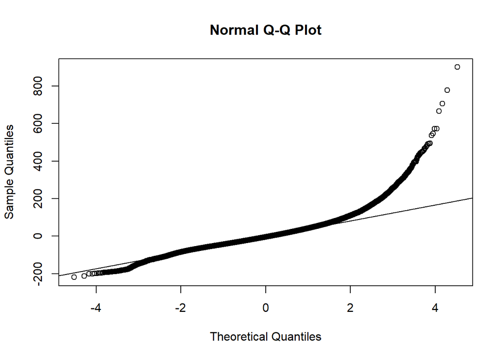

```r
qqnorm(lm$residuals)
qqline(lm$residuals)
```

##### 7.1.3.3 Are residuals homoskedastic?

1. First model which is not considering heteroskedasticity

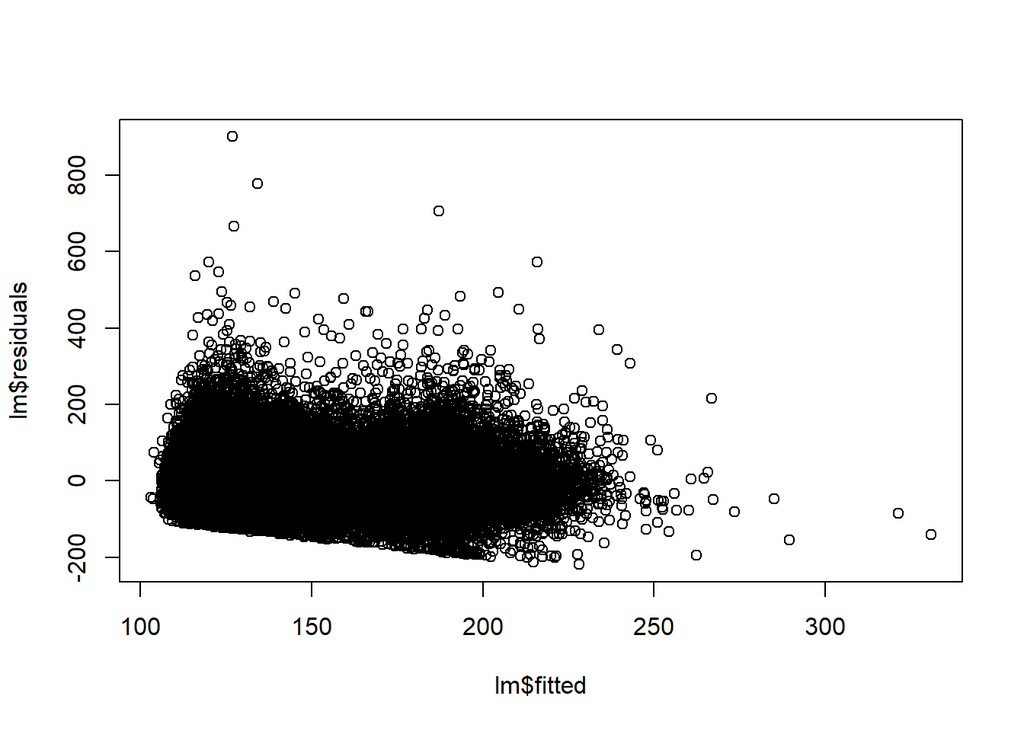

```r
plot(lm$residuals~lm$fitted)
```

```r
library(lmtest)
# Breush Pagan test H0 : homoskedasticity against H1 : heteroskedasticity

bptest(lm)
```

```
##
##  studentized Breusch-Pagan test
##
## data:  lm
## BP = 2239.7, df = 40, p-value < 2.2e-16
```

pvalue << 5%, we reject H0 residuals are heteroskedastic

In case of heteroskedasticity, we have to use a robust standard error estimator. Otherwise, all our t-tests will be wrong.

2. Second model taking into account heteroskedasticity

We calculate the robust covariance matrix

```r
library(sandwich)
vcov_y0 <- vcovHC(lm, type = "HC1")
coeftest(lm, vcov. = vcov_y0)
```

```
##
## t test of coefficients:
##
##                                               Estimate  Std. Error  t value
## (Intercept)                                -1.7421e+03  1.2710e+02 -13.7064
## alert.reason.category2                     -1.8685e+01  9.2106e-01 -20.2861
## alert.reason.category3                     -1.6990e+01  6.2786e-01 -27.0595
## alert.reason.category4                      3.4795e+00  1.6322e+00   2.1318
## alert.reason.category5                      1.8047e+01  3.7930e+00   4.7579
## alert.reason.category6                      1.2656e+01  1.0128e+00  12.4965
## alert.reason.category7                      2.6938e+01  3.7618e+00   7.1609
## alert.reason.category8                      7.0385e+00  3.8429e+00   1.8315
## alert.reason.category9                      3.7669e+00  8.6163e-01   4.3719
## longitude.intervention                      2.4304e+01  1.4147e+00  17.1794
## latitude.intervention                       3.8031e+01  2.5966e+00  14.6462
## delta.status.preceding.selection.selection  6.2062e-05  4.9377e-06  12.5691
## departed.from.its.rescue.center1           -2.5549e+00  9.3812e-01  -2.7234
## OSRM.estimated.distance                    -2.4948e-03  5.2900e-04  -4.7161
## OSRM.estimated.duration                     4.4547e-02  5.0658e-03   8.7937
## OSRM.estimated.speed                        1.1241e-01  3.8333e-02   2.9324
## hours01                                     1.5025e+01  1.0488e+00  14.3262
## hours02                                     2.7699e+01  1.1384e+00  24.3308
## hours03                                     3.2377e+01  1.1847e+00  27.3287
## hours04                                     3.5306e+01  1.2587e+00  28.0499
## hours05                                     3.5755e+01  1.2618e+00  28.3375
## hours06                                     1.8906e+01  1.2225e+00  15.4646
## hours07                                    -1.9443e+01  1.0544e+00 -18.4395
## hours08                                    -3.1067e+01  9.4702e-01 -32.8052
## hours09                                    -2.6510e+01  9.3268e-01 -28.4236
## hours10                                    -3.6849e+01  8.7700e-01 -42.0165
## hours11                                    -3.9176e+01  8.6615e-01 -45.2301
## hours12                                    -4.0035e+01  8.2627e-01 -48.4532
## hours13                                    -3.5994e+01  8.4550e-01 -42.5711
## hours14                                    -3.6671e+01  8.4597e-01 -43.3476
## hours15                                    -3.5741e+01  8.5382e-01 -41.8607
## hours16                                    -3.7403e+01  8.6637e-01 -43.1715
## hours17                                    -3.4015e+01  8.5510e-01 -39.7786
## hours18                                    -2.9320e+01  8.6035e-01 -34.0791
## hours19                                    -3.3562e+01  8.3594e-01 -40.1494
## hours20                                    -3.3535e+01  8.3792e-01 -40.0219
```

[output cut: 34 more lines]

```
## hours13                                    < 2.2e-16 ***
## hours14                                    < 2.2e-16 ***
## hours15                                    < 2.2e-16 ***
## hours16                                    < 2.2e-16 ***
## hours17                                    < 2.2e-16 ***
## hours18                                    < 2.2e-16 ***
## hours19                                    < 2.2e-16 ***
## hours20                                    < 2.2e-16 ***
## hours21                                    < 2.2e-16 ***
## hours22                                    < 2.2e-16 ***
## hours23                                    < 2.2e-16 ***
## emergency.vehicle.type.regroup             < 2.2e-16 ***
## rescue.center.regroup                      < 2.2e-16 ***
## ---
## Signif. codes:  0 '***' 0.001 '**' 0.01 '*' 0.05 '.' 0.1 ' ' 1
```